# Einführung in das Programmieren für Technische Mathematik

## `NumPy`-Arrays speichern und laden

NumPy bietet Funktionen zum Speichern und Laden von Arrays in verschiedenen Formaten:

- `np.save(filename, array)`: Speichert ein Array im `.npy`-Format.
- `np.load(filename)`: Lädt ein Array aus einer `.npy`-Datei.
- `np.savetxt(filename, array, delimiter=',')`: Speichert ein Array im Textformat (z.B. CSV).
  - Der optionale Parameter `delimiter` gibt das Trennzeichen an (Standard ist ein Leerzeichen).
- `np.loadtxt(filename, delimiter=',')`: Lädt ein Array aus einer Textdatei.

```python
import numpy as np
x=np.array([1, 2, 3])
np.save("data/array1.npy", x)
y=np.load("data/array1.npy")
print(y)
```

```
[1 2 3]
```

## 3D Plots mit Matplotlib und NumPy

Matplotlib unterstützt auch 3D-Plots.

- Zuerst muss mit `plt.figure()` eine Figur estellt werden
- Dann wird mit `add_subplot(111, projection='3d')` eine 3D-Achse hinzugefügt
  - Der erste Parameter `111` bedeutet, dass die Figur 1 Zeile und 1 Spalte hat und der Subplot an Position 1 ist
- anstatt den Subplot mit `subplot()` zu aktivieren, müssen wir Methoden der 3D-Achse verwenden
- `plot_surface()` wird verwendet, um eine 3D-Oberfläche zu plotten
- `cmap` steuert die Farbcodierung der Oberfläche
  - es gibt viele verschiedene Colormaps, z.B. 'viridis', 'plasma', 'inferno', 'magma', 'cividis', etc.
- `edgecolor='none'` entfernt die Kantenlinien der Oberfläche für eine glattere Darstellung
- `view_init(elev, azim)` ändert die Perspektive der 3D-Darstellung
  - `elev` ist der Höhenwinkel (Elevation) in Grad
  - `azim` ist der Azimutwinkel (Winkel zwischen x-Achse und der Blickrichtung) in Grad

Die Daten für den Surface-Plot müssen in einem Gitter vorliegen. Dies kann mit `numpy.meshgrid()` erreicht werden.

- `meshgrid()` erstellt zwei 2D-Arrays, die die x- und y-Koordinaten eines Gitters repräsentieren
- mit Inputs `X = [1,2,3]` und `Y = [4,5]` wird z.B. folgendes Gitter erstellt:

```
X = [[1,2,3],
     [1,2,3]]
 Y = [[4,4,4],
     [5,5,5]]
```

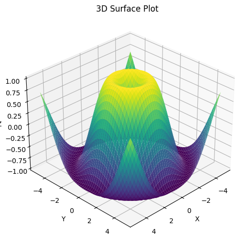

```python
import numpy as np
import matplotlib.pyplot as plt
X = np.linspace(-5, 5, 50)
Y = np.linspace(-5, 5, 50)
X, Y = np.meshgrid(X, Y)
Z = np.sin(np.sqrt(X**2 + Y**2))

fig = plt.figure(figsize=(8, 6))
ax = fig.add_subplot(111, projection='3d')
surf = ax.plot_surface(X, Y, Z, cmap='viridis', edgecolor='none')
ax.set_title('3D Surface Plot')
ax.set_xlabel('X')
ax.set_ylabel('Y')
ax.set_zlabel('Z')
ax.view_init(30, 45)
plt.show()
```

### Beispiel: Plot des Sonnensystems mit Copilot

Bei komplizierteren Plots lohnt sich oft der Einsatz von KI. Auch wenn das Ergebnis nicht immer perfekt ist, kann man es oft als guten Ausgangspunkt verwenden und dann weiter anpassen. Der folgende Code wurde mit dem Prompt "Create a 3d Plot of the solar system with the sun, earth and moon" erstellt.

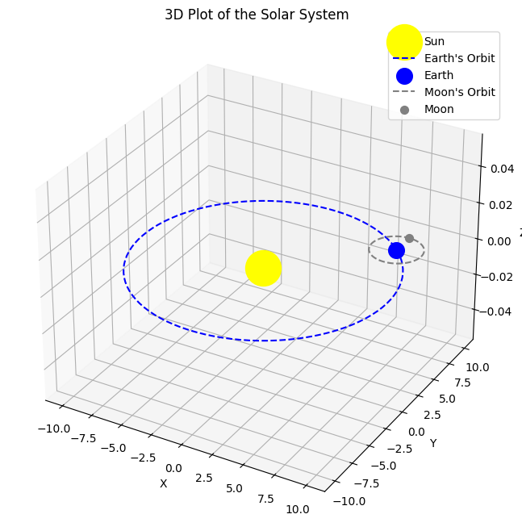

```python
# Create a new figure
fig_solar = plt.figure(figsize=(8, 8))
ax_solar = fig_solar.add_subplot(111, projection='3d')

# Plot the Sun
ax_solar.scatter(0, 0, 0, color='yellow', s=1000, label='Sun')  # Sun at the origin

# Plot the Earth's orbit
earth_orbit_radius = 10
theta = np.linspace(0, 2 * np.pi, 100)
earth_orbit_x = earth_orbit_radius * np.cos(theta)
earth_orbit_y = earth_orbit_radius * np.sin(theta)
earth_orbit_z = np.zeros_like(theta)
ax_solar.plot(earth_orbit_x, earth_orbit_y, earth_orbit_z, color='blue', linestyle='--', label="Earth's Orbit")

# Plot the Earth
earth_position = (earth_orbit_radius * np.cos(np.pi / 4), earth_orbit_radius * np.sin(np.pi / 4), 0)
ax_solar.scatter(*earth_position, color='blue', s=200, label='Earth')

# Plot the Moon's orbit around the Earth
moon_orbit_radius = 2
moon_theta = np.linspace(0, 2 * np.pi, 100)
moon_orbit_x = earth_position[0] + moon_orbit_radius * np.cos(moon_theta)
moon_orbit_y = earth_position[1] + moon_orbit_radius * np.sin(moon_theta)
moon_orbit_z = np.zeros_like(moon_theta)
ax_solar.plot(moon_orbit_x, moon_orbit_y, moon_orbit_z, color='gray', linestyle='--', label="Moon's Orbit")

# Plot the Moon
moon_position = (earth_position[0] + moon_orbit_radius * np.cos(np.pi / 2),
                 earth_position[1] + moon_orbit_radius * np.sin(np.pi / 2),
                 0)
ax_solar.scatter(*moon_position, color='gray', s=50, label='Moon')

# Set labels and title
ax_solar.set_title('3D Plot of the Solar System')
ax_solar.set_xlabel('X')
ax_solar.set_ylabel('Y')
ax_solar.set_zlabel('Z')
ax_solar.legend()

plt.show()
```

## Views (Ansichten) von NumPy Arrays

NumPy unterstützt das Konzept der "Views" (Ansichten), bei dem mehrere Variablen auf dasselbe Array im Speicher verweisen können.

- Änderungen an einer View wirken sich auf das Originalarray aus und umgekehrt.
- Der Unterschied zu normalen Variablenzuweisungen von `mutable` Objekten (wie Listen) ist, dass bei Views die Elemente des Arrays verschieden interpretiert werden können (z.B. andere Form oder nur ein Teil der Daten).
- Dieses Verhalten ist nützlich, um Speicherplatz zu sparen und die Leistung zu verbessern, da keine Kopien der Daten erstellt werden müssen.

Syntax:

```
view = array.view()
```

- Das direkte verwenden von `view()` oft nicht nötig, da viele Operationen automatisch eine View zurückgeben, z.B.
  - Slicing
  - `reshape()`

```python
a = np.arange(1,1000,2)
b = a[0:10] # erzeugt einen View auf die ersten 10 Elemente von a
print(b)
b[0] = 100
print(a[0])  # a wurde auch geändert, da b ein View ist

c = a.reshape((10,50))  # erzeugt einen View auf a mit neuer Form
print(c.shape)
c[0,1] = 200
print(a[1])  # a wurde auch geändert, da c ein View ist
```

```
[ 1  3  5  7  9 11 13 15 17 19]
100
(10, 50)
200
```

### Kopien von NumPy Arrays

- `copy = array.copy()`: Erstellt eine echte Kopie des Arrays im Speicher.
- Änderungen an der Kopie wirken sich nicht auf das Originalarray aus und umgekehrt.
  - nicht das selbe wie `copy.copy()` oder `copy.deepcopy()` aus dem Modul `copy`, da diese auch bei normalen Python-Listen verwendet werden können.
- Kopien von großen Arrays können teuer sein (allerdings erst ab tausenden oder millionen Elementen relevant).

```python
a = np.ones((3,3))
b = a.copy()  # erzeugt eine Kopie von a
b[0,0] = 100
print(a[0,0])  # a wurde nicht geändert, da b eine Kopie ist
print(b[0,0])  # b wurde geändert
```

```
1.0
100.0
```

### Beispiel für Views und Kopien

Folgende Illustration skizziert die Beziehung zwischen Originalarray, Shallow-Kopie, View und echter (Deep) Kopie

[figure not shown]

Hier ist:

- `A` das Original Array
- `B` eine Shallow-Kopie von `A` (z.B. durch Zuweisung `B = A`)
  - `A` und `B` teilen sich die Array-Struktur (Shape, Datentyp, etc.) und die Daten
- `C` eine View auf `A` (z.B. `C=A.reshape(6,1)`)
  - `A` und `C` teilen sich die Daten, aber interpretieren diese Daten durch unterschiedliche Array-Strukturen (in diesem Fall unterschiedliche Formen)
- `D` eine echte Kopie von `A` (z.B. `D=A.copy()`)
  - `A` und `D` sind komplett unabhängig, Änderungen an einem Array wirken sich nicht auf das andere aus

Beispiel in Code:

```python
A = np.array([[1, 2, 3], [4, 5, 6]])
B = A
C = A.reshape(6, 1)
D = A.copy()

D[0,0] = 100
print(A) # A wurde nicht geändert, da D eine Kopie ist
C[0,0] = 200
print(A) # A wurde auch geändert, da C ein View ist
B[0,0] = 300
print(A) # A wurde auch geändert, da B nur ein anderer Name für A ist
```

```
[[1 2 3]
 [4 5 6]]
[[200   2   3]
 [  4   5   6]]
[[300   2   3]
 [  4   5   6]]
```

### Unterscheiden zwischen Views und Kopien

Man kann überprüfen, ob ein Array eigentlich ein `View` ist indem man die `base` Eigenschaft des Arrays überprüft:

- Ist `array.base` `None`, dann ist `array` kein View, sondern ein Originalarray oder eine echte Kopie.
- Ist `array.base` nicht `None`, dann ist `array` ein View und `array.base` verweist auf das Originalarray, auf dem der View basiert.

```python
A = np.array([[1, 2, 3], [4, 5, 6]])
B = A
C = A[:2,:2]
D = A.copy()
print(B.base, B is A)  # None, da B kein View ist, True, da B nur ein anderer Name für A ist
print(C)
print(C.base, C is A)  # A, da C ein View auf A ist, False, da C nicht A ist
print(D.base, D is A)  # None, da D eine Kopie ist, False, da D nicht A ist
```

```
None True
[[1 2]
 [4 5]]
[[1 2 3]
 [4 5 6]] False
None False
```

# Matrix-Vector Operationen mit NumPy

NumPy ist eine leistungsstarke Bibliothek für numerische Berechnungen in Python, die insbesondere für die Arbeit mit Arrays und Matrizen optimiert ist.

**Matrizen** sind rechteckige Anordnungen von Zahlen, die in Zeilen und Spalten organisiert sind. Sie werden häufig in der linearen Algebra verwendet, um lineare Gleichungssysteme zu lösen, Transformationen durchzuführen und Daten zu analysieren.

$$ A = \begin{pmatrix} a_{11} & a_{12} & \cdots & a_{1n}\\ a_{21} & a_{22} & \cdots & a_{2n}\\ \vdots & \vdots & \ddots & \vdots\\ a_{m1} & a_{m2} & \cdots & a_{mn}\\ \end{pmatrix} \in \mathbb{R}^{m\times n} $$

### Matix-Matrix und Matrix-Vektor Operationen

- `*`: Elementweise Multiplikation von Arrays gleicher Form.
  - Alternative: `np.multiply()`
- `@` oder `np.dot()`: Matrix-Vektor- oder Matrix-Matrix-Multiplikation.
  - Für 1D-Arrays (Vektoren) wird das Skalarprodukt berechnet.
  - Für 2D-Arrays (Matrizen) wird die reguläre Matrixmultiplikation durchgeführt
    - Dimensionen müssen übereinstimmen: $A\in \mathbb{R}^{m\times n}, B\in \mathbb{R}^{n\times p} \Rightarrow C = A B \in \mathbb{R}^{m\times p}$ $$ C_{ij} = \sum_{k=1}^{n} A_{ik} B_{kj} \quad \text{für } i=1,\ldots,m \text{ und } j=1,\ldots,p $$
  - Alternative: `np.matmul()`
- `+`: Elementweise Addition von Arrays gleicher Form
- `-`: Elementweise Subtraktion von Arrays gleicher Form
- `/` : Elementweise Division von Arrays gleicher Form
- `np.transpose()`: Transponieren einer Matrix (Kurzform: `array.T`)

```python
import numpy as np
A = np.array([[1, 2, 3], [4, 5, 6]])
B = np.ones((3,2))
C = np.random.rand(2,3)
print(A)    # Originalmatrix
print(A@B)  # Matrix-Matrix Multiplikation
print(A*C)  # Elementwiese Matrix-Matrix Multiplikation
A = np.transpose(A)
print(A)    # Transponierte Matrix
print(A.T)  # Transponierte Matrix (Alternative)
```

```
[[1 2 3]
 [4 5 6]]
[[ 6.  6.]
 [15. 15.]]
[[0.69400846 0.09150452 0.7077927 ]
 [3.94595359 0.65573095 0.32543304]]
[[1 4]
 [2 5]
 [3 6]]
[[1 2 3]
 [4 5 6]]
```

### Broadcasting Regeln

- Wenn die Dimensionen der Arrays nicht übereinstimmen, versucht NumPy, sie durch Broadcasting kompatibel zu machen.
- Zwei Dimensionen sind kompatibel, wenn sie gleich sind oder eine von ihnen 1 ist.
- NumPy dehnt die Dimension mit der Größe 1 so aus, dass sie der anderen Dimension entspricht.
- Wenn die Arrays unterschiedliche Anzahlen von Dimensionen haben, fügt NumPy der kleineren Anzahl von Dimensionen linksseitig Dimensionen hinzu, bis die Anzahlen übereinstimmen.

Im folgenden Beispiel ist $A\in \mathbb{R}^{3\times 1}$ und $B\in \mathbb{R}^{1\times 4}$. Durch Broadcasting wird $A$ zu einer $3\times 4$ Matrix und $B$ zu einer $3\times 4$ Matrix erweitert, sodass die Addition möglich ist.

```python
A = np.ones((3,1))
B = np.ones((1,4))
C = A + B  # Ergebnis ist ein 3x4 Array, da A und B durch Broadcasting kompatibel gemacht wurden
print("A:")
print(A)
print("B:")
print(B)
print("C:")
print(C)
```

```
A:
[[1.]
 [1.]
 [1.]]
B:
[[1. 1. 1. 1.]]
C:
[[2. 2. 2. 2.]
 [2. 2. 2. 2.]
 [2. 2. 2. 2.]]
```

Im nächsten Beispiel wird $A\in \mathbb{R}^{3\times 4}$ mit dem Vektor $B\in \mathbb{R}^{4}$ elementweise multipliziert. Durch Broadcasting wird $B$ zu einer $3\times 4$ Matrix erweitert (es werden linkseitig Dimensionen hinzugefügt), sodass die Multiplikation möglich ist.

```python
A = np.ones((3,4))
B = np.array([1, 2, 3, 4])
C = A * B
print("A:")
print(A)
print("B:")
print(B)
print("C:")
print(C)
```

```
A:
[[1. 1. 1. 1.]
 [1. 1. 1. 1.]
 [1. 1. 1. 1.]]
B:
[1 2 3 4]
C:
[[1. 2. 3. 4.]
 [1. 2. 3. 4.]
 [1. 2. 3. 4.]]
```

Durch Broadcasting kann man Arrays auch sehr einfach mit Skalaren kombinieren. Ein Skalar wird dabei so erweitert, dass er die gleiche Form wie das andere Array hat.

```python
A = np.array([[1, 2, 3], [4, 5, 6]])
print(A+1) # Addiert 1 zu jedem Element von A
print(A*2) # Multipliziert jedes Element von A mit 2
print(A**2) # Quadriert jedes Element von A
```

```
[[2 3 4]
 [5 6 7]]
[[ 2  4  6]
 [ 8 10 12]]
[[ 1  4  9]
 [16 25 36]]
```

**Wichtig**: Matrix-Matrix-Multiplikation `@` folgt etwas anderen Broadcasting Regeln.

- Ist der erste Operand 1D, so werden linkseitig Dimensionen hinzugefügt.
- Ist der zweite Operand 1D, so werden rechtseitig Dimensionen hinzugefügt.
- Nach der Multiplikation werden alle hinzugefügten Dimensionen entfernt.

```python
A = np.array([[1, 2, 3], [4, 5, 6]])
B = np.array([1, 2, 3])
C = np.array([1,2])
print(A@B) # Broadcasting erweitert B zu einer 3x2 Matrix
print(C@A) # Broadcasting erweitert C zu einer 2x2 Matrix
```

[output not shown]

## Logische Operationen auf Arrays

- `np.all(array)`: Gibt `True` zurück, wenn alle Elemente des Arrays `True` sind.
- `np.any(array)`: Gibt `True` zurück, wenn mindestens ein Element des Arrays `True` ist.
- `array1 & array2`: Elementweise logisches UND zwischen zwei Arrays gleicher Form.
- `array1 | array2`: Elementweise logisches ODER zwischen zwei Arrays gleicher Form.
- `~array`: Elementweise logisches NICHT eines Arrays gleicher Form.
- `array1 == array2`: Elementweise Gleichheitsprüfung zwischen zwei Arrays gleicher Form.
- `array1 != array2`: Elementweise Ungleichheitsprüfung zwischen zwei Arrays gleicher Form.
- `array1 < array2`: Elementweise Kleiner-als-Prüfung zwischen zwei Arrays gleicher Form.
- `array1 <= array2`: Elementweise Kleiner-gleich-Prüfung zwischen zwei Arrays gleicher Form.

```python
a = np.array([1,2,3,4,5])
b = np.array([2,3,4,5,6])
c = np.array([1,2,3,4,6])
print("Is a[i]<b[i] for all i?", np.all(a < b))
print("Is a[i]<c[i] for all i?", np.all(a < c))
print("Is a[i]<c[i] for any i?", np.any(a < c))
```

```
Is a[i]<b[i] for all i? True
Is a[i]<c[i] for all i? False
Is a[i]<c[i] for any i? True
```

```python
a = np.arange(100)
b = a % 2 == 0
c = a % 3 == 0
d = a % 5 == 0
result = a[ b & c & d ]
print(f"Es gibt {len(result)} Zahlen <100, die durch 2, 3 und 5 teilbar sind: {result}")
```

```
Es gibt 4 Zahlen <100, die durch 2, 3 und 5 teilbar sind: [ 0 30 60 90]
```

**Achtung**: Im Gegensatz zu `and`, `or` die für einzelne boolesche Werte verwendet werden, kann man `&` und `|` nicht einfach verketten.

```
a < b < c  # FALSCH
  (a < b) & (b < c)  # RICHTIG
```

In der ersten Zeile wird zuerst `a < b` ausgewertet, was ein Array von booleschen Werten ergibt. Dann wird versucht, dieses Array mit `c` zu vergleichen, was zu einem Fehler führt.

### Diagonal & Block-Matrizen

- `np.diag(v)`: Erstellt eine Diagonalmatrix mit den Elementen von `v` auf der Hauptdiagonale.
- `np.diag(A)`: Extrahiert die Hauptdiagonale der Matrix `A` und gibt sie als 1D-Array zurück.
- `np.diag(v,k)`: Erstellt eine Matrix mit den Elementen von `v` auf der k-ten Diagonale (k>0 oberhalb der Hauptdiagonale, k<0 unterhalb).

```python
v = np.array([1, 2, 3])
A = np.diag(v)
print("A:")
print(A)
M = np.random.rand(3,3)
print("M:")
print(M)
print("np.diag(M):")
print(np.diag(M))
```

```
A:
[[1 0 0]
 [0 2 0]
 [0 0 3]]
M:
[[0.04871182 0.1274668  0.91988157]
 [0.07219462 0.30163947 0.73460621]
 [0.92643805 0.90740011 0.8032583 ]]
np.diag(M):
[0.04871182 0.30163947 0.8032583 ]
```

```python
v = np.array([1, 2, 3,4])
w = np.array([5,6,7])
A = np.diag(v) + np.diag(w, k=1) + np.diag(-w, k=-1)
print("A:")
print(A)
```

```
A:
[[ 1  5  0  0]
 [-5  2  6  0]
 [ 0 -6  3  7]
 [ 0  0 -7  4]]
```

- `np.block([[A, B], [C, D]])`: Erstellt eine Blockmatrix aus den Matrizen `A`, `B`, `C` und `D`.
- `np.hstack([A,B])`: Horizontales Stapeln von Arrays (nebeneinander).
- `np.vstack([A,B])`: Vertikales Stapeln von Arrays (untereinander).

```python
A = np.array([[1, 2, 3], [4, 5, 6]])
B = np.zeros((2, 2))
C = np.ones((1,3))
D = np.array([[1,3]])
M = np.block([[A, B], [C, D]])
print("A:")
print(A)
print("B:")
print(B)
print("C:")
print(C)
print("D:")
print(D)
print("M:")
print(M)
```

[output not shown]

### Weitere nützliche Funktionen im `numpy.linalg` Submodul

- `np.linalg.inv(A)`: Berechnet die Inverse der Matrix `A`, falls sie existiert.
- `np.linalg.pinv(A)`: Berechnet die Pseudoinverse der Matrix `A`.
- `np.linalg.det(A)`: Berechnet die Determinante der Matrix `A`.
- `np.linalg.eig(A)`: Berechnet die Eigenwerte und Eigenvektoren der Matrix `A`.
- `np.linalg.svd(A)`: Führt die Singulärwertzerlegung (SVD) der Matrix `A` durch.
- `np.linalg.norm(v,p)`: Berechnet die p-Norm eines Vektors `v`. Standardmäßig die 2-Norm (Euklidische Norm).
  - Für Vektoren:
    - `p=1`: Summe der absoluten Werte
    - `p=2`: Euklidische Norm
    - `p=np.inf`: Maximum der absoluten Werte
  - Für Matrizen:
    - `p='fro'`: Frobenius-Norm
    - `p=2`: Spektralnorm (größter Singulärwert)
    - `p=1`: Maximale Spaltensumme
    - `p=np.inf`: Maximale Zeilensumme

```python
A=np.array([[1, 2], [3, 4]])
print("Determinant of A: ", np.linalg.det(A))
print("2-Norm of A: ", np.linalg.norm(A,2))
print("Inverse of A: ")
B = np.linalg.inv(A)
print(B)
# Überprüfung: A @ A^-1 = I
print("A @ A^-1 = I:")
print(A @ B)
```

```
Determinant of A:  -2.0000000000000004
2-Norm of A:  5.464985704219043
Inverse of A:
[[-2.   1. ]
 [ 1.5 -0.5]]
A @ A^-1 = I:
[[1.0000000e+00 0.0000000e+00]
 [8.8817842e-16 1.0000000e+00]]
```

Im obigen Beispiel sieht man sehr schöne, dass selbt einfachste Rechnungen mit Rundungsfehlern behaftet sind. Die Multiplikation von `A` mit ihrer Inversen ergibt nicht exakt die Einheitsmatrix, sondern nur eine Näherung davon.

- Erinnerung: `8.8817e-16` steht für $8.8817 \cdot 10^{-16}= 0.0000000000000008817$, also eine sehr kleine Zahl nahe bei Null.

### Beispiel: Regressionslinie hinzufügen

Eine Regressionslinie zeigt die allgemeine Tendenz in den Daten. Wenn man Datenpunkte $(x_i, y_i)$, $i=1,\ldots,n$ hat, sucht man eine gerade Linie $y = mx + b$, die die Summe der quadrierten Abstände zu den Punkten minimiert, also die Summe $$ \sum_{i=1}^n (y_i - (mx_i + b))^2 $$ minimiert. Dies wird als Methode der kleinsten Quadrate bezeichnet. Mit `numpy.polyfit` kann man das sehr schnell berechnen.

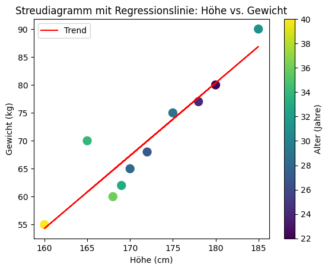

```python
# Höhe (cm) = people_data[:, 0], Gewicht (kg) = people_data[:, 1]
x_data = people_data[:, 0]
y_data = people_data[:, 1]

# Lineare Regression mit numpy.polyfit
m, b = np.polyfit(x_data, y_data, 1)
regression_line = m * x_data + b

plt.scatter(x_data, y_data, c=people_data[:, 2], s=100)
plt.plot(x_data, regression_line, color='red', label=f'Trend')
plt.colorbar(label='Alter (Jahre)')
plt.title('Streudiagramm mit Regressionslinie: Höhe vs. Gewicht')
plt.xlabel('Höhe (cm)')
plt.ylabel('Gewicht (kg)')

plt.legend()
plt.show()
```

### Gleichungssysteme lösen:

- `np.linalg.solve(A, b)`: Löst das lineare Gleichungssystem `Ax = b` für `x`, wobei `A` eine quadratische Matrix ist.
- **Achtung**: `np.linalg.inv(A)` sollte vermieden werden, um Gleichungssysteme zu lösen, da es numerisch instabil sein kann und ineffizient ist (mehr dazu in der Vorlesung "Numerische Mathematik").

Im folgenden Beispiel wollen wir das einfache Gleichungssystem $$ 2x_1 + 3x_2 = 8 \\ 5x_1 + 7x_2 = 19 $$ lösen. Dazu schreiben wir es in Matrixform $Ax = b$ mit $$ A = \begin{pmatrix} 2 & 3 \\ 5 & 7 \end{pmatrix}, \quad x = \begin{pmatrix} x_1 \\ x_2 \end{pmatrix}, \quad b = \begin{pmatrix} 8 \\ 19 \end{pmatrix} $$ Mathematisch erhält man die Lösung durch $x = A^{-1}b$. In Python verwenden wir jedoch `np.linalg.solve(A, b)` um Rundungsfehler zu minimieren.

```python
A = np.array([[2,3],[5,7]])
b = np.array([8,19])
x = np.linalg.solve(A,b)
print("Lösung x von Ax=b:")
print("x=",x)
```

```
Lösung x von Ax=b:
x= [1. 2.]
```

**Numerische Instabilität**: Im folgenden Beispiel wollen wir demonstrieren, dass verschiedene Methoden die mathematisch äquivalent sind, am Computer unterschiedliche Ergebnisse liefern können.

- Der Grund dafür sind Rundungsfehler, die bei der Berechnung auftreten können.
- Manche Algorithmen sind weniger anfällig für diese Fehler als andere, weshalb es wichtig ist, die numerische Stabilität von Algorithmen zu berücksichtigen.

- Für $\varepsilon = 0$ wäre die Matrix singulär (nicht invertierbar) und daher das Gleichungssystem nicht eindeutig lösbar
  - In "Linearer Algebra" lernen Sie diesen Zusammenhang genauer kennen.
  - Für uns reicht es zu wissen, dass $\varepsilon =0 $ zum folgendem Gleichungssystem führt: $$ x_1 + x_2 = b_1\\ x_1 + x_2 = b_2 $$
  - wenn $b_1 \neq b_2$ gibt es keine Lösung, wenn $b_1 = b_2$ gibt es unendlich viele Lösungen.
- Für kleine Werte von $\varepsilon$ ist die Matrix $A$ zwar invertierbar und das Gleichungssystem hat eine Eindeutige Lösung. Aber die Matrix ist so nahe an einer singulären Matrix, das numerische Problemen auftreten können.

```python
A = np.array([[1, 1+1e-14], [1+1e-14, 1]])
x_exact = np.array([2, 2])
b = A @ x_exact

# Lösung mit np.linalg.solve
x_solve = np.linalg.solve(A, b)

# Lösung mit Inverser Matrix
x_inv = np.linalg.inv(A) @ b

print("Fehler mit np.linalg.solve:", np.linalg.norm(x_solve - x_exact))
print("Fehler mit np.linalg.inv(A) @ b:", np.linalg.norm(x_inv - x_exact))
```

```
Fehler mit np.linalg.solve: 4.440892098500626e-16
Fehler mit np.linalg.inv(A) @ b: 0.012767205771416977
```

### Beispiel: Bilder laden und bearbeiten

- `mathplotlib.pyplot.imread()`: Lädt ein Bild und gibt es als NumPy-Array zurück.
- `mathplotlib.pyplot.imsave()`: Speichert ein NumPy-Array als Bild
- `mathplotlib.pyplot.imshow()`: Zeigt ein Bild aus einem NumPy-Array an.

Bilder werden in der Regel als 3D-Arrays gespeichert, wobei die erste Dimension die Höhe (Anzahl der Pixel in vertikaler Richtung), die zweite Dimension die Breite (Anzahl der Pixel in horizontaler Richtung) und die dritte Dimension die Farbkanäle (z.B. Rot, Grün, Blau für RGB-Bilder) repräsentiert.

- Die Farbwerte sind in der Regel im Bereich von 0 bis 255 für 8-Bit-Bilder oder von 0.0 bis 1.0 für normalisierte Bilder.

```
Image shape: (1024, 1024, 3)
```

```
(-0.5, 1023.5, 1023.5, -0.5)
```

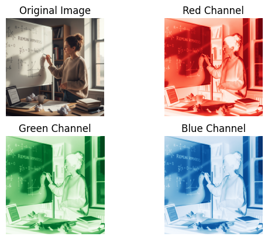

```python
import matplotlib.pyplot as plt
import numpy as np

img = plt.imread('data/img.png')  # Bild laden
print("Image shape:", img.shape)  # Bildabmessungen anzeigen
plt.subplot(2,2,1)
plt.title("Original Image")
plt.imshow(img)                   # Originalbild anzeigen
plt.axis('off')
plt.subplot(2,2,2)
plt.title("Red Channel")
plt.imshow(img[:,:,0], cmap='Reds')  # Roter Kanal anzeigen
plt.axis('off')
plt.subplot(2,2,3)
plt.title("Green Channel")
plt.imshow(img[:,:,1], cmap='Greens') # Grüner Kanal anzeigen
plt.axis('off')
plt.subplot(2,2,4)
plt.title("Blue Channel")
plt.imshow(img[:,:,2], cmap='Blues')  # Blauer Kanal anzeigen
plt.axis('off')
```

Um das Bild in Graustufen umzuwandeln, kann man einfach den Durchschnitt der Farbkanäle berechnen. Dies reduziert die dritte Dimension des Arrays auf 1.

- Ein natürlicheres Ergebnis erhält man mit der Luminanzmethode, die die unterschiedlichen Wahrnehmungen der Farben durch das menschliche Auge berücksichtigt.
- Dabei werden die Farbkanäle mit den Gewichten 0.2989 für Rot, 0.5870 für Grün und 0.1140 für Blau gewichtet.

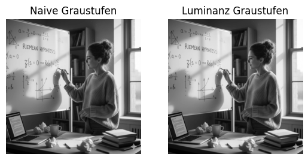

```python
grayscale_naive = img @ np.array([1/3, 1/3, 1/3])
grayscale_luminance = img @ np.array([0.2989, 0.5870, 0.1140])

plt.subplot(1,2,1)
plt.title("Naive Graustufen")
plt.imshow(grayscale_naive, cmap='gray')
plt.axis('off')
plt.subplot(1,2,2)
plt.title("Luminanz Graustufen")
plt.imshow(grayscale_luminance, cmap='gray')
plt.axis('off')
plt.show()
tmp = np.zeros((grayscale_luminance.shape[0], grayscale_luminance.shape[1],3))
tmp[...,0] = grayscale_luminance
tmp[...,1] = grayscale_luminance
tmp[...,2] = grayscale_luminance
plt.imsave('data/grayimg.png', tmp)
```

# Performance von Python mit NumPy und Vektoroperationen

- NumPy ist besonders nützlich, weil es viel schneller ist als Standard-Python-Listen für numerische Berechnungen.

Im folgenden Beispiel vergleichen wir die Zeit, die benötigt wird, um die Summe der Quadrate von 0 bis 9.999.999 zu berechnen

- einmal mit einer Python-Liste
- einmal mit einem NumPy-Array.

```python
import numpy as np
import time

start = time.time()
my_list = [x**2 for x in range(int(1e7))]
end = time.time()
print("Zeit für Liste:", end - start)

start = time.time()
my_array = np.arange(int(1e7))**2
end = time.time()
print("Zeit für NumPy-Array:", end - start)
```

```
Zeit für Liste: 1.701355218887329
Zeit für NumPy-Array: 0.022548675537109375
```

Der Grund für die höhere Geschwindigkeit von NumPy liegt darin, dass NumPy-Arrays in C implementiert sind und Operationen auf ihnen in optimiertem maschinennahen Code ausgeführt werden, während Python-Listen in Python selbst implementiert sind und daher langsamer sind.

- `ndarray`-Daten liegen als zusammenhängende Blöcke im Speicher vor, was die Cache-Ausnutzung verbessert und die Leistung erhöht.
- NumPy nutzt Vektoroperationen, die auf mehreren Datenpunkten gleichzeitig arbeiten können, was die Effizienz weiter steigert und parallele Verarbeitung ermöglicht.

## Vermeidung von Python-Schleifen

- Python-Schleifen sind im Allgemeinen langsamer als Vektoroperationen mit NumPy.
- Versuchen Sie, Schleifen zu vermeiden, indem Sie stattdessen NumPy-Funktionen und -Operationen verwenden.

**Beispiel elementweise Operationen:** Im folgenden Beispiel wollen wir alle Elemente des Vektors `vec` auf Null setzen, die entweder durch 3 oder durch 5 teilbar sind.

```python
vec = np.arange(1e7)

# Mit Schleife
start = time.time()
for i,x in enumerate(vec):
    if x % 3 == 0 or x % 5 == 0:
        vec[i] = 0
end = time.time()
print("Zeit für Schleife:", end - start)

# Mit Vektoroperation
vec = np.arange(1e7)
start = time.time()
vec[(vec % 3 == 0) | (vec % 5 == 0)] = 0
end = time.time()
print("Zeit für Vektoroperation:", end - start)
```

```
Zeit für Schleife: 2.1751160621643066
Zeit für Vektoroperation: 0.39929962158203125
```

### Beispiel `np.sum()`

Die Methode `np.sum()` kann verwendet werden um die Summe aller Elemente in einem NumPy-Array zu berechnen.

- `np.sum(A, axis=k)` berechnet die Summe entlang der Achse `k` (0 für Spalten, 1 für Zeilen) und gibt ein Array mit den Summen zurück.
- Ohne Angabe von `axis` wird die Summe aller Elemente im Array berechnet und als Skalar zurückgegeben.

Im folgenden Beispiel erstellen wir eine zufällige Matrix $A\in \{-1,1\}^{n\times n}$ und berechnen die Summe aller Elemente in $A$ sowie die Summe jeder Spalte und jeder Zeile.

```python
# erstellen eine kleinen zufälligen -1,1-Matrix
A = np.random.rand(5,5)
A[A < 0.5] = -1
A[A >= 0.5] = 1
print("Matrix A:\n", A)
# alternative kann man die choice-Methode verwenden
A = np.random.choice([-1, 1], size=(5,5))
print("Matrix A:\n", A)

print("Summe aller Elemente in A:", np.sum(A))
print("Summe jeder Spalte in A:", np.sum(A, axis=0))
print("Summe jeder Zeile in A:", np.sum(A, axis=1))
```

```
Matrix A:
 [[-1. -1. -1.  1.  1.]
 [ 1.  1. -1.  1.  1.]
 [ 1.  1. -1.  1.  1.]
 [ 1.  1. -1.  1. -1.]
 [-1. -1.  1. -1.  1.]]
Matrix A:
 [[-1  1  1 -1 -1]
 [-1  1 -1 -1 -1]
 [-1  1  1 -1  1]
 [ 1  1  1 -1  1]
 [ 1 -1 -1 -1  1]]
Summe aller Elemente in A: -1
Summe jeder Spalte in A: [-1  3  1 -5  1]
Summe jeder Zeile in A: [-1 -3  1  3 -1]
```

Wenn wir $n$ nun sehr groß wählen, dann sehen wir, dass `np.sum` sehr viel schneller ist als eine Python-Schleife.

```python
n = 10000
# erstellen eine großen zufälligen -1,1-Matrix
A = np.random.choice([-1, 1], size=(n,n))
start = time.time()
total_sum = np.sum(A)
end = time.time()
print(f"Summe aller Elemente in A (n={n}):", total_sum)
print("Zeit für np.sum:", end - start)

start = time.time()
total_sum = 0
for i in range(n):
    for j in range(n):
        total_sum += A[i,j]
end = time.time()
print(f"Summe aller Elemente in A (n={n}):", total_sum)
print("Zeit für Schleife:", end - start)
```

```
Summe aller Elemente in A (n=10000): 5776
Zeit für np.sum: 0.029768943786621094
Summe aller Elemente in A (n=10000): 5776
Zeit für Schleife: 11.10342264175415
```

### Weitere Operationen auf Arrays

- `np.mean(A, axis=k)` berechnet den Mittelwert entlang der Achse `k`.
- `np.std(A, axis=k)` berechnet die Standardabweichung entlang der Achse `k`.
- `np.min(A, axis=k)` und `np.max(A, axis=k)` finden das Minimum bzw. Maximum entlang der Achse `k`.
- `np.argmin(A, axis=k)` und `np.argmax(A, axis=k)` geben die Indizes des Minimums bzw. Maximums entlang der Achse `k` zurück.
- `np.sort(A, axis=k)` sortiert die Elemente entlang der Achse `k`.
- `np.unique(A)` gibt die eindeutigen Elemente im Array zurück.

Das NumPy Modul bietet viele weitere Funktionen für die Arbeit mit Arrays, die alle darauf ausgelegt sind, effizient und schnell zu sein.

- Es lohnt sich, die Dokumentation zu durchsuchen https://numpy.org/doc/stable/
- Alternativ können Sie CoPilot fragen
  - "Welche Funktionen bietet NumPy für die Arbeit mit Arrays?"
  - "How can I compute the the row-sum of a matrix in NumPy?"

## Initialisierung von Arrays (Aufwand)

- Die Erstellung eines NumPy-Arrays erfordert die Reservierung eines zusammenhängenden Speicherblocks
- Wenn das Array verlängert wird, muss möglicherweise ein neuer Speicherblock reserviert und die Daten kopiert werden, was zeitaufwändig sein kann.
- Um dies zu vermeiden, reserviert man bereits zu Beginn genügend Speicherplatz, z.B. durch `np.zeros((n,m))` oder `np.empty((n,m))` (falls die Längen `n` und `m` bekannt sind).

```python
import numpy as np
import time
n = 2**16
start = time.time()
x = np.zeros((n,), dtype=int)
for i in range(n):
    x[i] = i
end = time.time()
print("Zeit mit Initialisierung ", end - start)

start = time.time()
x = np.zeros((1,), dtype=int)
for i in range(1,n):
    x = np.append(x,i)
end = time.time()
print("Zeit ohne Initialisierung", end - start)

start = time.time()
x = np.arange(n, dtype=int)
end = time.time()
print("Zeit mit arange", end - start)

start = time.time()
x = np.array(range(n), dtype=int)
end = time.time()
print("Zeit mit array und range", end - start)
```

```
Zeit mit Initialisierung  0.010347843170166016
Zeit ohne Initialisierung 0.452303409576416
Zeit mit arange 0.0001900196075439453
Zeit mit array und range 0.0021712779998779297
```

## Effiziente Funktionsaufrufe

Ein Grundprinzip in Python lautet: **Funktionen sollten keine Nebeneffekte haben.**

- Das bedeutet, dass eine Funktion keine Variablen außerhalb ihres eigenen Gültigkeitsbereichs ändern sollte.
- **Problem**: Bei sehr großen Arrays kann das erstellen einer Kopie sehr aufwändig sein
- **Lösung**: Grundprinzip ignorieren aber Nebeneffekte genau dokumentieren

```python
import numpy as np
import time
n = 10**8
def copy_vector(vec):
    # Create a copy of the vector to avoid modifying the original
    vec_copy = vec.copy()
    vec_copy[0] = -1
    return vec_copy

def inplace_vector(vec):
    '''Sets the first element of the vector to -1 by modifying the original vector (inplace).'''
    vec[0] = -1  # Set even numbers to -1


# Original vector
large_vector = np.arange(n)

start = time.time()
x = copy_vector(large_vector)
end = time.time()
print("Zeit für Kopie:", end - start)
print("Originalvektor nach Kopie-Funktion (sollte unverändert sein):", large_vector[0])

start = time.time()
inplace_vector(large_vector)
end = time.time()
print("Zeit für Inplace:", end - start)
print("Originalvektor nach Inplace-Funktion (sollte verändert sein):", large_vector[0])
```

```
Zeit für Kopie: 0.10150814056396484
Originalvektor nach Kopie-Funktion (sollte unverändert sein): 0
Zeit für Inplace: 2.47955322265625e-05
Originalvektor nach Inplace-Funktion (sollte verändert sein): -1
```

## `out`-Parameter in `NumPy`

Viele NumPy-Funktionen bieten einen `out`-Parameter, der es ermöglicht, das Ergebnis einer Operation in einem bereits existierenden Array zu speichern, anstatt ein neues Array zu erstellen. Dies kann die Leistung verbessern, da es die Notwendigkeit reduziert, zusätzlichen Speicher zuzuweisen und Daten zu kopieren.

```python
import numpy as np
import time
n = 10**7
x = np.random.rand(n)
y = np.random.rand(n)
res = np.zeros((n,))

# Using the out parameter to save the result in an existing array
start = time.time()
for _ in range(100):
    np.multiply(x, y, out=res)  # Element-wise multiplication, result stored in 'res'
    np.add(res, x, out=res)  # Element-wise addition, result stored in 'res'
end = time.time()
print("Zeit mit out-Parameter:", end - start)

# Without using the out parameter (creates a new array)
start = time.time()
for _ in range(100):
    result = x*y
    result = result + x  # Element-wise multiplication, result stored in a new array
end = time.time()
print("Zeit ohne out-Parameter:", end - start)
```

```
Zeit mit out-Parameter: 1.562828540802002
Zeit ohne out-Parameter: 3.0910451412200928
```

## Beispiel: Die Fläche von Österreich berechnen

Eine wichtige Methode in der numerischen Mathematik ist die **Monte-Carlo-Methode**. Ein Anwendung der Methode ist die Berechnung von Flächeninhalten.

- Man umgibt die zu berechnende Fläche mit einem Rechteck, dessen Fläche leicht zu berechnen ist.
- Dann generiert man zufällige Punkte innerhalb dieses Rechtecks.
- Der Anteil der Punkte, die innerhalb der zu berechnenden Fläche liegen, entspricht dem Verhältnis der Flächeninhalte.

Wir erinnern uns an die Funktion die überprüft ob ein Punkt innerhalb eines Polygons liegt

```python
import numpy as np
import matplotlib.pyplot as plt
# Funktion, die überprüft, ob ein Punkt innerhalb eines Polygons liegt
def inside_poly(poly, point):
    x, y = point
    n = len(poly)
    counter = 0

    for i in range(n):
        x1, y1 = poly[i]
        x2, y2 = poly[(i + 1) % n]
        if ((y1 > y) != (y2 > y)) and (x < (x2 - x1) * (y - y1) / (y2 - y1) + x1):
            counter += 1

    return counter % 2 == 1
```

Der nächste Code-Block lädt die Eckpunkte eines Polygons das die Grenzen von Österreich approximiert und berechnet das kleinste umgebende Rechteck (Bounding Box). Die Fläche der Bounding Box wird approximativ mit Werten aus einem Online Kartendienst berechnet (Länge x Breite).

- Die Eckpunkte des Polygons sind in der Datei `data/austria_vertices.npy` gespeichert.
- Die Datei wurde durch manuelles Nachzeichnen der Grenzen von Österreich in einem Online-Kartendienst erstellt

```python
# Box um Österreich
austria_vertices = np.load("data/austria_vertices.npy")


bounding_box = np.array([np.min(austria_vertices[:,0]), np.min(austria_vertices[:,1]),
                         np.max(austria_vertices[:,0]), np.max(austria_vertices[:,1])])
box_area = 562 * 287  # ca. Fläche der Bounding Box in km²
```

Schließlich generieren wir zufällige Punkte innerhalb der Bounding Box und überprüfen, wie viele davon innerhalb des Polygons liegen. Daraus können wir den Flächeninhalt von Österreich abschätzen.

```python
# Generiere zufällige Punkte innerhalb der Bounding Box
samples = 2000
random_points = np.random.rand(samples, 2)
random_points[:, 0] = random_points[:, 0] * (bounding_box[2] - bounding_box[0]) + bounding_box[0]
random_points[:, 1] = random_points[:, 1] * (bounding_box[3] - bounding_box[1]) + bounding_box[1]

# Überprüfe, ob die Punkte innerhalb oder außerhalb des Polygons liegen
inside_count = 0
for point in random_points:
    if inside_poly(austria_vertices, point):
        inside_count += 1
print(f"Anteil der Punkte innerhalb von Österreich: {inside_count/samples:.2%}")
print(f"Geschätzte Fläche von Österreich: {inside_count/samples * box_area:.2f} (tatsächlich ca. 83883 km²)")
```

```
Anteil der Punkte innerhalb von Österreich: 51.90%
Geschätzte Fläche von Österreich: 83711.59 (tatsächlich ca. 83883 km²)
```

Letztlich visualisieren wir das Polygon, die Bounding Box und die zufällig generierten Punkte.

[figure not shown]

```python
# Visualisierung der Berechnung
plt.figure(figsize=(8, 8))
plt.plot(austria_vertices[:, 0], austria_vertices[:, 1], 'b-', marker='o')
plt.fill(austria_vertices[:, 0], austria_vertices[:, 1], alpha=0.2, color='blue')
plt.plot([bounding_box[0], bounding_box[2], bounding_box[2], bounding_box[0], bounding_box[0]],
         [bounding_box[1], bounding_box[1], bounding_box[3], bounding_box[3], bounding_box[1]], 'r--')
plt.scatter(random_points[:,0], random_points[:,1], color='green', s=1, alpha=0.5)
plt.xticks([])
plt.yticks([])
plt.axis('equal')
plt.show()
```

# Zahldarstellung im Computer

## Speichereinheiten

- **1 Bit**= 1 b = kleinste Einheit, speichert $0$ oder $1$
- **1 Byte**= 1 B = Zusammenfassung von 8 Bit
- **1 Kilobyte**= 1 KB = 1024 Byte
  - $1024 = 2^{10}$ nächste 2er Potenz an $1000$
- **1 Megabyte**= 1 MB = 1024 KB
- **1 Gigabyte**= 1 GB = 1024 MB
- **1 Terabyte**= 1 TB = 1024 GB

## Speicherung von Zahlen

- Zur Speicherung von Zahlen wird je nach Datentyp fixe Anzahl an Bytes verwendet
- **Konsequenz:**
  - pro Datentyp gibt es nur endlich viele Zahlen
  - es gibt jeweils größte und kleinste Zahl!

## Ganzzahlen

- Mit $n$ Bits kann man $ 2^n$ Ganzzahlen darstellen
- Standardmäßig betrachtet man
  - entweder alle ganzen Zahlen in $[0,2^n-1]$
  - oder alle ganzen Zahlen in $[-2^{n-1},2^{n-1}-1]$

## Integer-Arithmetik in Python

Integer Arithmetik in Python unterscheidet sich von vielen andern Programmiersprachen, da es __keine zu großen Integer-Zahlen__gibt.

- Python kann mit beliebig großen Zahlen exakt rechnen
  - Ausnahme: Speicherplatz im Computer reicht nicht um die Zahl zu speichern
  - Extrem unwahrscheinlich: 1 MB Speicher reicht für Zahlen mit ca. $8\cdot 10^6$ binären Ziffern, also ca. $2.4\cdot 10^6$ Dezimalziffern.
    - Begründung: 1 MB sind ca. 10^6 Bytes = $8\cdot 10^6$ Bits
    - Ein Bit speichert eine binäre Ziffer
    - Um eine Dezimalziffer zu speichern, benötigt man ca. 3.32 Bits ($\log_2(10) \approx 3.32$)
- Viele andere Programmiersprachen (C, C++, Java, ...) haben feste Grenzen für Integer-Zahlen
  - z.B. 32-Bit Integer: Zahlenbereich $[-2^{31},2^{31}-1] = [-2147483648, 2147483647]$
  - z.B. 64-Bit Integer: Zahlenbereich $[-2^{63},2^{63}-1] = [-9223372036854775808, 9223372036854775807]$
  - Werden diese Grenzen überschritten, kommt es zu einem **Überlauf**(engl. overflow)
    - z.B. in C/C++/Java: $2147483647 + 1 = -2147483648$
    - In Python gibt es keinen Überlauf, aber
      - Rechenoperationen mit sehr großen Zahlen sind deutlich langsamer als mit kleinen Zahlen

### **Achtung**: Integer-Arithmetik in `NumPy`

Aus Performance-Gründen verwendet die `NumPy` Bibliothek für numerische Rechnungen in Python standardmäßig 64-Bit Integer.

- Exakte Arithmetik ist nur innerhalb des Bereichs $[-2^{63},2^{63}-1]$ gewährleistet.
- Bei Überschreitung dieses Bereichs kommt es zu einem Überlauf, ähnlich wie in anderen Programmiersprachen.
- Modulo-Arithmetik: größte Zahl + 1 = kleinste Zahl
- Python gibt meistens eine Warnung aus, wenn ein Überlauf auftritt.

Es gibt auch die Möglichkeit, in `NumPy` mit größeren Integer-Typen zu rechnen, z.B. `np.int128`, wenn die Plattform dies unterstützt. Allerdings sind diese Typen nicht so weit verbreitet und können in manchen Umgebungen nicht verfügbar sein.

Kleinere Integer-Typen wie `np.int8`, `np.int16`, und `np.int32` sind ebenfalls verfügbar, aber sie haben noch kleinere Wertebereiche und sind daher anfälliger für Überläufe. - Rechnungen in kleineren Integer-Typen sind schneller als in größeren Integer-Typen.

```python
import numpy as np

x = np.array([1, 2, 3], dtype=np.int64)
x[0] = 2**63-1
x[0] += 1
print(x[0])
```

```
-9223372036854775808
```

### Beispiel: unsigned 4-bit Integer

Um zu erklären, wie es zum Überlauf kommt, betrachten wir die Darstellung von Zahlen im Binärsystem mit 4 Bits (4 Speicherplätzen für 0/1).

- 4 Speicherplätze für 0/1 $\implies$ 16 verschiedene Zahlen ($0,\ldots, 15$)
- Formel: $a_3 a_2 a_1 a_0= \sum_{i=0}^3 a_i2^i$ mit $a_i\in\{0,1\}$
- **0 0 0 0**$= 0$
- **0 0 0 1**$= 1$
- **0 0 1 0**$= 2$
- **0 0 1 1**$= 3$
- $\ldots$
- **1 0 0 0**$= 8$
- $\ldots$
- **1 1 1 1**$= 15$
- Addition wie im 10er System (mit Übertrag falls Ergebnis $>1$)
  - **0 0 0 1**+ **0 1 0 1**= **0 1 1 0** ($1+5=6$)

### Beispiel: 4-bit Integer

- 4 Speicherplätze für 0/1 $\implies$ 16 verschiedene Zahlen ($-8,\ldots,0,\ldots, 7$)
- **0 0 0 0**$= 0$
- $\ldots$
- **0 1 1 1**$= 7$
- Beobachtung: **0 1 1 1**+ **1 0 0 1**= **0 0 0 0**($+1$ Übertrag bleibt übrig)
- daher: **1 0 0 1**$= -7$
- **1 0 0 0**$= -8$
- $\ldots$
- **1 1 1 1**$= -1$
- Daher: **0 1 1 1**+**0 0 0 1**= **1 0 0 0** (Überlauf $7+1=-8$)

## `np.int32` hat nicht viel PLatz

Kleinere Datentypen sind zwar schneller, haben aber deutlich weniger Platz für Zahlen.

- Größter Wert für `np.int32`: $2^{31}-1 = 2147483647 \approx 2.1$ Milliarden
- **Achtung:**$13! = 13\cdot 12! > 13\cdot 479\cdot10^6 > 6$ Millarden

```python
import numpy as np
x = np.array([1], dtype=np.int32)
for i in range(17):
    x[0] *= (i+1)
    print(f"{i+1:2d}! = {x[0]}")
```

```
 1! = 1
 2! = 2
 3! = 6
 4! = 24
 5! = 120
 6! = 720
 7! = 5040
 8! = 40320
 9! = 362880
10! = 3628800
11! = 39916800
12! = 479001600
13! = 1932053504
14! = 1278945280
15! = 2004310016
16! = 2004189184
17! = -288522240
```

**Achtung**: Überlauf-Fehler wird zwar angezeigt, aber erst bei $17!$. **Das Ergebnis ist ab $13!$ schon falsch.**

## Codierung von Zeichen

Strings sind Folgen von Zeichen.

- Jedes Zeichen wird durch eine Zahl codiert.
- Festgelegt im Unicode-Standard (UTF-8)
- Den Zahlencode eines Zeichen kann man mit der Funktion `ord` herausfinden.
- Umgekehrt kann man mit der Funktion `chr` aus einem Zahlencode das entsprechende Zeichen zurückgewinnen.
  - Oft wird der Unicode in hexadezimaler Schreibweise angegeben: `0x...`

```python
for c in "abcdefghijklmnopqrstuvwxyz":
    print(f"The Unicode of '{c}' is {ord(c)}")

print("Cats are great " + chr(0x1F63B)*10)
```

```
The Unicode of 'a' is 97
The Unicode of 'b' is 98
The Unicode of 'c' is 99
The Unicode of 'd' is 100
The Unicode of 'e' is 101
The Unicode of 'f' is 102
The Unicode of 'g' is 103
The Unicode of 'h' is 104
The Unicode of 'i' is 105
The Unicode of 'j' is 106
The Unicode of 'k' is 107
The Unicode of 'l' is 108
The Unicode of 'm' is 109
The Unicode of 'n' is 110
The Unicode of 'o' is 111
The Unicode of 'p' is 112
The Unicode of 'q' is 113
The Unicode of 'r' is 114
The Unicode of 's' is 115
The Unicode of 't' is 116
The Unicode of 'u' is 117
The Unicode of 'v' is 118
The Unicode of 'w' is 119
The Unicode of 'x' is 120
The Unicode of 'y' is 121
The Unicode of 'z' is 122
Cats are great 😻😻😻😻😻😻😻😻😻😻
```

# Gleitkommazahlen

Reelle Zahlen werden im Computer in der Regel als Gleitkommazahlen (engl. floating point numbers) gespeichert. Der Name kommt daher, dass die Position des Dezimalpunkts (bzw. Binärpunkts) "gleiten" kann, abhängig von der Größe der Zahl.

## Gleitkommadarstellung

Folgender mathematischer Satz formalisiert die Idee der Gleitkommadarstellung:

- **SATZ:** Zu $ x\in\mathbb{R}$ existieren
  - Vorzeichen $\sigma\in\{\pm1\}$
  - Ziffern $ a_k\in\{0,1\}$
  - Exponent $ e\in\mathbb{Z}$ sodass gilt $\displaystyle x = \sigma\Bigg(\sum_{k=1}^\infty a_k2^{-k}\Bigg)2^e$
- Darstellung ist nicht eindeutig, da z.B. $1 = \displaystyle\sum_{k=1}^\infty2^{-k}$
  - geometrische Reihe: $\displaystyle \sum_{k=0}^\infty 2^{-k} = \frac{1}{1-1/2} = 2$
  - z.B. $\displaystyle \Bigg( \sum_{k=1}^\infty 2^{-k} \Bigg) 2^0 = \sum_{k=1}^\infty 2^{-k} = 1 = \Bigg( \sum_{k=2}^\infty 2^{-k} \Bigg) 2^1$

### Bemerkungen zum Dezimalsystem

- Satz gilt für jede Basis $ b\in\mathbb{N}_{\ge2}$
  - Ziffern dann $ a_j\in\{0,1,\dots,b-1\}$
- Dezimalsystem $b=10$ ist übliches System
  - $47.11 = (4\cdot10^{-1}+7\cdot10^{-2}+1\cdot10^{-3}+1\cdot10^{-4})\cdot10^2$ * $a_1=4$, $a_2=7$, $a_3=1$, $a_4=1$, $e=2$
- Nichteindeutigkeit im Dezimalsystem: $0.\overline{9} = 1$

### Bemerkungen zum Binärsystem

- Mit $b=2$ sind gekürzte Brüche genau dann als endliche Summe darstellbar (nicht als unendliche Reihe), wenn der Nenner Zweierpotenz ist:
  - $\displaystyle\sum_{k=1}^{ M}a_k 2^{-k}$ hat Nenner mit Zweierpotenz
  - Folgt aus Eindeutigkeit der Primfaktorzerlegung
  - formaler Beweis = freiwillige Übung
- z.B. keine exakte Darstellung für $1/10$ für $b=2$

## Definition von Gleitkommazahlensystemen

- Gleitkommazahlsystem $\mathbb{F}(2,M,e_{\rm min},e_{\rm max})\subset\mathbb{Q}$
  - endliche Teilmenge!
  - Mantissenlänge $ M\in\mathbb{N}$
  - Exponentialschranken $ e_{\rm min}<0<e_{\rm max}$
- $ x\in\mathbb{F}$ hat Darstellung $\displaystyle x = \sigma\Bigg(\sum_{k=1}^M a_k2^{-k}\Bigg)2^e$ mit
  - Vorzeichen $\sigma\in\{\pm1\}$
  - Ziffern $ a_j\in\{0,1\}$ mit $ a_1=1$ oder $ e = e_{\rm min}$ * normalisierte Gleitkommazahl ($ a_1=1$) * denormalisierte Gleitkommazahl ($ e = e_{\rm min}$)
  - Exponent $ e\in\mathbb{Z}$ mit $ e_{\rm min}\le e\le e_{\rm max}$
- Darstellung von $ x\in\mathbb{F}$ ist eindeutig (Übung!)
- Ziffer $a_1$ muss nicht gespeichert werden
  - implizites erstes Bit

## Arithmetik für Gleitkommazahlen

- Ergebnis **Inf**, **-Inf__bei Überlauf (oder __1./0.**)
  - $+\infty$ (**Inf**), $-\infty$ (**-Inf**)
- Ergebnis **NaN**, falls nicht definiert (z.B. **0./0.**)
  - *not a number* (**NaN**)
- Arithmetik ist approximativ, nicht exakt

## Schlechte Kondition

- Eine Aufgabe ist **numerisch schlecht gestellt__bzw. __schlecht konditioniert**, falls kleine Änderungen der Daten auf große Änderungen im Ergebnis führen
  - z.B. hat Dreieck mit gegebenen Seitenlängen einen rechten Winkel?
  - z.B. liegt gegebener Punkt auf Kreisrand?
- **Implementierung sinnlos, weil Ergebnis zufällig!**
- bessere Fragestellungen:
  - Hat ein Dreieck mit gegebenen Seitenlängen einen Winkel $\approx 90^\circ$?
  - Liegt ein Punkt in einem $\varepsilon$-Schlauch um den Kreisrand?

### Rechenfehler

- Aufgrund von Rechenfehlern darf man Gleitkommazahlen **nie auf Gleichheit überprüfen** - Statt $x=y$ prüfen, ob Fehler $|x-y|$ klein ist - z.B. $|x-y|\le\varepsilon\cdot\max\{|x|,|y|\}$ mit $\varepsilon=10^{-13}$
- In `NumPy` gibt es die Funktion `np.isclose(x, y, atol=..., rtol=...)`, die prüft, ob zwei Gleitkommazahlen `x` und `y` "nahe beieinander" liegen. Dabei sind `atol` und `rtol` absolute bzw. relative Toleranzen.
  - Die Funktion überprüft, ob die Bedingung `abs(x - y) <= atol + rtol * abs(y)` erfüllt ist.

```python
print("0.1 + 0.2 = 0.3?", 0.1 + 0.2 == 0.3)
print(f"0.1 is actually {0.1:.30f}")


print("(116/100)*100 = 116", (116./100)*100 == 116)
print(f"(116/100)*100 is actually {(116./100)*100:.30f}")

print("0.1 + 0.2 = 0.3 up to round-off error?", np.isclose(0.1 + 0.2, 0.3))
print("(116/100)*100 = 116 up to round-off error?", np.isclose((116./100)*100, 116))
```

```
0.1 + 0.2 = 0.3? False
0.1 is actually 0.100000000000000005551115123126
(116/100)*100 = 116 False
(116/100)*100 is actually 115.999999999999985789145284797996
0.1 + 0.2 = 0.3 up to round-off error? True
(116/100)*100 = 116 up to round-off error? True
```

## Variablentypen `np.float32`, `np.float64`

- `np.float32` ist idR. einfache Genauigkeit nach IEEE-754-Standard
  - $\mathbb{F}(2,24,-126,127)$ $\to$ 4 Byte = 32 Bit * 32b = 8b Exp. + 23b Mantisse + 1b Vorz.
  - sog. *single precision*
  - ca. 7 signifikante Dezimalstellen
- `np.float64` ist idR. doppelte Genauigkeit nach IEEE-754-Standard
  - $\mathbb{F}(2,53,-1022,1023)$ $\to$ 8 Byte = 64 Bit * 64b = 11b Exp. + 52b Mantisse + 1b Vorz.
  - sog. *double precision*
  - ca. 16 signifikante Dezimalstellen

```python
x32 = np.array(0.1, dtype=np.float32)
x64 = np.array(0.1, dtype=np.float64)
print(f"float32: 0.1 is actually {x32:.30f}")
print(f"float64: 0.1 is actually {x64:.30f}")
```

```
float32: 0.1 is actually 0.100000001490116119384765625000
float64: 0.1 is actually 0.100000000000000005551115123126
```

# Vererbung in Python

## Was ist Vererbung?

**Vererbung** (engl. Inheritance) ist ein fundamentales Konzept der objektorientierten Programmierung, das es ermöglicht, neue Klassen basierend auf bestehenden Klassen zu erstellen.

- Eine **Basisklasse** (auch Elternklasse oder Superklasse) definiert gemeinsame Eigenschaften und Methoden.
- Eine **abgeleitete Klasse** (auch Kindklasse oder Unterklasse) erbt diese Eigenschaften und Methoden und kann sie erweitern oder überschreiben.

### Warum ist Vererbung wichtig?

1. **Code-Wiederverwendung**: Gemeinsamer Code muss nur einmal geschrieben werden und kann in mehreren Klassen verwendet werden.
2. **Hierarchische Strukturierung**: Vererbung ermöglicht es, natürliche Hierarchien zu modellieren (z.B. Tiere → Säugetiere → Hunde).
3. **Erweiterbarkeit**: Bestehende Klassen können erweitert werden, ohne den ursprünglichen Code zu ändern.

### Relevanz in der Mathematik und Wissenschaft

- **Geometrie**: Geometrische Formen (Polygon → Dreieck, Viereck, etc.) haben gemeinsame Eigenschaften.
- **Numerische Methoden**: Verschiedene Lösungsverfahren können von einer gemeinsamen Basisklasse abgeleitet werden.
- **Datenstrukturen**: Spezialisierte Arrays oder Matrizen können von NumPy-Klassen erben und zusätzliche mathematische Funktionalität bieten.
- **Simulation**: Verschiedene physikalische Objekte können gemeinsame Eigenschaften (Position, Geschwindigkeit) erben.

## Syntax der Vererbung

Die Syntax zur Definition einer abgeleiteten Klasse in Python ist:

```
class DerivedClass(BaseClass):
    # Erweiterungen und Überschreibungen
```

Die abgeleitete Klasse erbt automatisch alle Attribute und Methoden der Basisklasse.

- Wird eine Methode der Basisklasse in der abgeleiteten Klasse nochmals definiert, so spricht man von **Überschreiben** (engl. Overriding).
  - In der abgeleiteten Klasse wird die Methode der Basisklasse durch die Methode der abgeleiteten Klasse ersetzt.
  - Die Methode der Basisklasse kann mit `super()` aufgerufen werden.

### Beispiel: Einfache Vererbung

```python
class Animal:
    def __init__(self, name):
        self.name = name

    def speak(self):
        return f"{self.name} macht ein Geräusch"

class Dog(Animal):
    def speak(self):
        return f"{self.name} bellt: Wuff!"

class Cat(Animal):
    def speak(self):
        return f"{self.name} miaut: Miau!"

# Verwendung
animal = Animal("Tier")
dog = Dog("Bello")
cat = Cat("Minka")

print(animal.speak())
print(dog.speak())
print(cat.speak())
```

```
Tier macht ein Geräusch
Bello bellt: Wuff!
Minka miaut: Miau!
```

In diesem Beispiel:

- `Dog` und `Cat` erben von `Animal`
- Beide überschreiben die `speak()` Methode mit spezifischem Verhalten
- Das `name` Attribut wird von `Animal` geerbt und muss nicht neu definiert werden

### Aufruf der Methode der Basisklasse

Man kann noch immer erzwingen, dass die Methode der Basisklasse aufgerufen wird.

```python
print(Animal.speak(dog))  # Erzwingt Aufruf der Methode der Basisklasse
print(Animal.speak(cat))  # Erzwingt Aufruf der Methode der Basisklasse
print(dog.speak())  # Ruft die Methode der abgeleiteten Klasse auf
print(cat.speak())  # Ruft die Methode der abgeleiteten Klasse auf
```

```
Bello macht ein Geräusch
Minka macht ein Geräusch
Bello bellt: Wuff!
Minka miaut: Miau!
```

## Die `super()` Funktion

Die `super()` Funktion ermöglicht es, Methoden der Basisklasse aus der abgeleiteten Klasse aufzurufen. Dies ist besonders nützlich, wenn:

- Der Konstruktor der Basisklasse aufgerufen werden soll
- Eine Methode erweitert (nicht vollständig überschrieben) werden soll

Syntax:

```
super().__init__(parameters)  # Konstruktor der Basisklasse
super().method_name(parameters)  # Methode der Basisklasse
```

### Beispiel: Verwendung von `super()`

In diesem Beispiel wird der Konstruktor der Basisklasse aufgerufen um `brand` und `model` zu initialisieren, bevor das neue Attribut `num_doors` hinzugefügt wird.

```python
class Vehicle:
    def __init__(self, brand, model):
        self.brand = brand
        self.model = model

    def info(self):
        return f"{self.brand} {self.model}"

class Car(Vehicle):
    def __init__(self, brand, model, num_doors):
        super().__init__(brand, model)  # Ruft Konstruktor der Basisklasse auf
        self.num_doors = num_doors      # Neues Attribut hinzufügen

    def info(self):
        base_info = super().info()  # Ruft Methode der Basisklasse auf
        return f"{base_info} mit {self.num_doors} Türen"

car = Car("VW", "Golf", 5)
print(car.info())
```

```
VW Golf mit 5 Türen
```

## Praktisches Beispiel: Geometrische Formen

Geometrische Formen sind ein klassisches Beispiel für Vererbung. Wir definieren eine Basisklasse `Shape` und leiten daraus verschiedene spezifische Formen ab.

- Oft dient die Basisklasse nur als Bauplan und gibt nur Methoden vor die später implementiert werden müssen (abstrakte Klasse).
  - `NotImplementedError` wird ausgelöst um das zu signalisieren.

```python
class Shape:
    """Basisklasse für geometrische Formen"""
    def __init__(self, name):
        self.name = name

    def area(self):
        raise NotImplementedError("Unterklassen müssen die area() Methode implementieren")

    def perimeter(self):
        raise NotImplementedError("Unterklassen müssen die perimeter() Methode implementieren")

    def describe(self):
        return f"{self.name}: Fläche = {self.area():.2f}, Umfang = {self.perimeter():.2f}"

class Rectangle(Shape):
    """Rechteck als Unterklasse von Shape"""
    def __init__(self, width, height):
        super().__init__("Rechteck")
        self.width = width
        self.height = height

    def area(self):
        return self.width * self.height

    def perimeter(self):
        return 2 * (self.width + self.height)

class Circle(Shape):
    """Kreis als Unterklasse von Shape"""
    def __init__(self, radius):
        super().__init__("Kreis")
        self.radius = radius

    def area(self):
        return 3.14159 * self.radius ** 2

    def perimeter(self):
        return 2 * 3.14159 * self.radius

class Triangle(Shape):
    """Dreieck als Unterklasse von Shape"""
    def __init__(self, a, b, c):
        super().__init__("Dreieck")
        self.a = a
        self.b = b
        self.c = c

    def area(self):
        # Heronsche Formel
        s = self.perimeter() / 2
        return (s * (s - self.a) * (s - self.b) * (s - self.c)) ** 0.5

    def perimeter(self):
        return self.a + self.b + self.c

# Verwendung
shapes = [
    Rectangle(4, 5),
    Circle(3),
    Triangle(3, 4, 5)
]

for shape in shapes:
    print(shape.describe())
```

```
Rechteck: Fläche = 20.00, Umfang = 18.00
Kreis: Fläche = 28.27, Umfang = 18.85
Dreieck: Fläche = 6.00, Umfang = 12.00
```

Dieses Beispiel zeigt:

- **Gemeinsame Schnittstelle**: Alle Formen haben `area()` und `perimeter()` Methoden
- **Code-Wiederverwendung**: Die `describe()` Methode wird nur einmal in der Basisklasse definiert
- **Polymorphismus**: Wir können verschiedene Formen in einer Liste speichern und einheitlich behandeln
- **Erweiterbarkeit**: Neue Formen können einfach hinzugefügt werden, ohne bestehenden Code zu ändern

## Erweiterte Vererbungshierarchie

Vererbung kann über mehrere Ebenen erfolgen. Wir erweitern unser Beispiel mit einer Spezialisierung:

```python
class Square(Rectangle):
    """Quadrat als Spezialfall des Rechtecks"""
    def __init__(self, side):
        super().__init__(side, side)  # Ruft Rectangle-Konstruktor auf
        self.name = "Quadrat"
        self.side = side

    def diagonal(self):
        """Zusätzliche Methode für Quadrate"""
        return self.side * (2 ** 0.5)

    def describe(self):
        base_desc = super().describe()
        return f"{base_desc}, Diagonale = {self.diagonal():.2f}"

square = Square(4)
print(square.describe())
```

```
Quadrat: Fläche = 16.00, Umfang = 16.00, Diagonale = 5.66
```

Hier erbt `Square` von `Rectangle`, das wiederum von `Shape` erbt. Das Quadrat:

- Nutzt die Implementierung des Rechtecks für Fläche und Umfang
- Fügt eine zusätzliche `diagonal()` Methode hinzu
- Erweitert die `describe()` Methode

## Vererbung und Statische Attribute

- Statische Attribute der Basisklasse sind von abgeleiteten Klassen zugänglich.
  - Python sucht zuerst in der Instanz (falls man über eine Instanz darauf zugreift), dann in der Klasse und schließlich in der Basisklasse nach dem Attribut.
  - Änderungen an einem statischen Attribut in der Basisklasse wirken sich auf alle abgeleiteten Klassen aus, sofern diese das Attribut nicht überschreiben.
- Wenn man in der abgeleiteten Klasse ein statisches Attribut ändert, passiert dies nur für diese Klasse und nicht für die Basisklasse oder andere abgeleitete Klassen.
  - Der Grund ist, dass Python das Attribut in der abgeleiteten Klassen nicht findet und es daher in der abgeleiteten Klasse neu anlegt.
  - Das Attribut der Basisklasse (mit dem gleichen Namen) wird verdeckt.

```python
class A:
    a = 10  # Statisches Attribut der Basisklasse
class B(A):
    def __init__(self):
        self.b = 20 # Instanzattribut der abgeleiteten Klasse, unwichtig für das Beispiel
class C(A):
    def __init__(self):
        self.c = 30 # Instanzattribut der abgeleiteten Klasse, unwichtig für das Beispiel


print(f"A.a = {A.a}, B.a = {B.a}, C.a = {C.a}")
B.a = 30  # Erstellt ein neues statisches Attribut für die Klasse B, verdeckt aber das Attribut der Basisklasse A
print(f"A.a = {A.a}, B.a = {B.a}, C.a = {C.a}")
A.a = 40  # Überschreibt das statische Attribut für die Instanz A und damit auch für C, da C das Attribut von A erbt
print(f"A.a = {A.a}, B.a = {B.a}, C.a = {C.a}")
```

```
A.a = 10, B.a = 10, C.a = 10
A.a = 10, B.a = 30, C.a = 10
A.a = 40, B.a = 30, C.a = 40
```

## Subclassing von existierenden Klassen

Python erlaubt es, von manchen externen Klassen zu erben, um spezialisierte Funktionalität zu implementieren.

### Die `__new__` und `__del__` Methoden

Die `__new__` Methode ist eine weitere magische Methode in Python, die für die Erstellung einer neuen Instanz einer Klasse verantwortlich ist. Sie wird aufgerufen, bevor der Konstruktor `__init__` ausgeführt wird und gibt ein neues Objekt der Klasse zurück.

Die `__del__` Methode wird aufgerufen, wenn eine Instanz der Klasse gelöscht wird. Sie kann verwendet werden, um Aufräumarbeiten durchzuführen, bevor das Objekt aus dem Speicher entfernt wird. Üblicherweise wird `__del__` aufgerufen, wenn keine Variable mehr auf das Objekt verweist. Da Python eine automatische Speicherbereinigung (Garbage Collection) verwendet, ist die Verwendung von `__del__` in der Praxis eher selten.

Syntax:

```
def __new__(cls, *args, **kwargs):
    # Erstellen und Rückgabe einer neuen Instanz
    return #new_instance

def __del__(self):
    # Aufräumarbeiten vor der Löschung der Instanz
```

```python
class Test():
    def __new__(cls):
        print("Creating instance")
        instance = super().__new__(cls)
        return instance
    def __init__(self):
        print("Initializing instance")
        self.value = 0
    def __del__(self):
        print("Deleting instance")

# Create instance of Test
test = Test()
# Let variable test point to something else, triggering __del__ since no reference to instance of Test remains
test = 5.0
```

```
Creating instance
Initializing instance
Deleting instance
```

### Verwendung von `__new__` um von unveränderlichen Typen zu erben

Die `__new__` Methode wird besonders wichtig, wenn man von unveränderlichen Typen wie `int`, `str` oder `tuple` erben möchte. Da diese Typen nicht verändert werden können, muss die `__new__` Methode verwendet werden, um eine neue Instanz zu erstellen.

```python
class UnitFloat(float):
    def __new__(cls,value, unit):
        instance = super().__new__(cls,value)
        instance.unit = unit
        return instance

    def __str__(self):
        return str(self.real)+" "+self.unit

    def __add__(self, other):
        if isinstance(other, UnitFloat) and self.unit != other.unit:
            raise ValueError(f"Cannot add {self.unit} and {other.unit}")
        return UnitFloat(super().__add__(other), self.unit)

    def __truediv__(self, other):
        if isinstance(other, UnitFloat):
            return UnitFloat(super().__truediv__(other), f"{self.unit}/{other.unit}")
        return UnitFloat(super().__truediv__(other), self.unit)

    def __mul__(self, other):
        return UnitFloat(super().__mul__(other), f"{self.unit}")

    __rmul__ = __mul__


length = UnitFloat(42.195,"km")
time = UnitFloat(2.0, "hours")
print(f"A Marathon is {length} and the world record is just above {time}")
print(f"The average speed is {length/time}")
print(f"A quarter-marathon is {length/4}")
```

```
A Marathon is 42.195 km and the world record is just above 2.0 hours
The average speed is 21.0975 km/hours
A quarter-marathon is 10.54875 km
```

### Rückblick `view()`

Zur Erinnerung: Die `view()` Methode in NumPy erstellt eine neue Ansicht (View) eines Arrays mit einem anderen Datentyp oder einer anderen Klasse, ohne die zugrunde liegenden Daten zu kopieren.

- `view()` hat einen Parameter `type`, der es ermöglicht, den View als eine benutzerdefinierte Klasse zu interpretieren, die von `ndarray` erbt.

### NumPy-Klassen erweitern?

Ein nützliches Beispiel ist, die `ndarray` Klasse zu erweitern, um spezialisierte Array-Typen mit zusätzlicher Funktionalität zu erstellen.

1. **Domänenspezifische Operationen**: Zusätzliche mathematische Operationen, die für spezielle Anwendungen relevant sind
2. **Validierung**: Automatische Überprüfung von Daten (z.B. nur positive Werte, normalisierte Vektoren)
3. **Metadaten**: Zusätzliche Informationen zu den Daten (z.B. Einheiten, Namen)
4. **Benutzerdefiniertes Verhalten**: Spezielle Darstellung oder Operationen für wissenschaftliche Anwendungen

### Beispiel: Vektor-Klasse mit zusätzlichen Methoden

Wir erweitern die `ndarray` Klasse, um eine `Vector` Klasse zu erstellen, die zusätzliche Methoden für Vektorrechnung bietet.

- `norm`: Berechnet die euklidische Norm des Vektors $|v|^2 = v_1^2 + v_2^2 + ... + v_d^2$
- `angle_with`: Berechnet den Winkel $\theta$ zwischen zwei Vektoren $v$ und $w$ mit der Formel $$ \cos(\theta) = \frac{v \cdot w}{|v| \cdot |w|} $$

```python
import numpy as np

class Vector(np.ndarray):
    """Erweiterte Vektor-Klasse mit zusätzlichen mathematischen Operationen"""

    def __new__(cls, input_array):
        # Input array wird in ndarray konvertiert und als Vector behandelt
        obj = np.array(input_array).view(type=cls)
        return obj

    def norm(self):
        """Berechnet die euklidische Norm (Länge) des Vektors"""
        return np.sqrt(np.sum(self ** 2))

    def normalize(self):
        """Gibt einen normalisierten Vektor (Länge 1) zurück"""
        n = self.norm()
        if n == 0:
            raise ValueError("Kann Nullvektor nicht normalisieren")
        return Vector(self / n)

    def angle_with(self, other):
        """Berechnet den Winkel (in Grad) zwischen diesem und einem anderen Vektor"""
        dot_product = np.dot(self, other)
        cos_angle = dot_product / (self.norm() * Vector(other).norm())
        # Numerische Stabilität: cos_angle kann durch Rundungsfehler außerhalb [-1, 1] liegen
        cos_angle = np.clip(cos_angle, -1.0, 1.0)
        angle_rad = np.arccos(cos_angle)
        return np.degrees(angle_rad)

    def is_orthogonal_to(self, other, tolerance=1e-10):
        """Prüft, ob dieser Vektor orthogonal zu einem anderen ist"""
        return abs(np.dot(self, other)/ (self.norm() * Vector(other).norm())) < tolerance

# Verwendung
v1 = Vector([3, 4])
v2 = Vector([4, -3])
v3 = Vector([1, 0])

print(f"Vektor v1: {v1}")
print(f"Länge von v1: {v1.norm():.2f}")
print(f"Normalisierter v1: {v1.normalize()}")
print(f"Winkel zwischen v1 und v2: {v1.angle_with(v2):.2f}°")
print(f"Sind v1 und v2 orthogonal? {v1.is_orthogonal_to(v2)}")
print(f"Winkel zwischen v1 und v3: {v1.angle_with(v3):.2f}°")
```

```
Vektor v1: [3 4]
Länge von v1: 5.00
Normalisierter v1: [0.6 0.8]
Winkel zwischen v1 und v2: 90.00°
Sind v1 und v2 orthogonal? True
Winkel zwischen v1 und v3: 53.13°
```

In diesem Beispiel:

- Die `Vector` Klasse erbt von `np.ndarray`
- `__new__` wird verwendet (statt `__init__`), da NumPy Arrays unveränderliche Größe haben
- Zusätzliche Methoden wie `norm()`, `normalize()`, `angle_with()` und `is_orthogonal_to()` werden hinzugefügt
- Alle Standard-NumPy-Operationen funktionieren weiterhin (Addition, Multiplikation, etc.)

### Beispiel: Fast orthogonale Vektoren finden

In $\mathbb{R}^d$ können höchstens $d$ orthogonale Vektoren existieren. Wir können jedoch versuchen, eine größere Menge von Vektoren zu finden, die "fast" orthogonal zueinander sind, indem wir eine Toleranz für den Winkel zwischen den Vektoren zulassen.

Eine gute Methode ist, zufällige Vektoren zu generieren und zu überprüfen, ob sie innerhalb der Toleranz orthogonal zu den bereits ausgewählten Vektoren sind. Wenn ja, fügen wir sie zur Menge hinzu. Dabei verwenden wir `randn()` um normalverteilte Zufallszahlen zu generieren, was in höheren Dimensionen oft zu besser verteilten Vektoren führt.

```
Es wurden 28 fast orthogonale Vektoren gefunden:
```

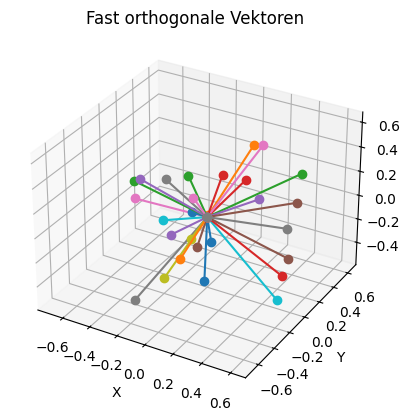

```python
import matplotlib.pyplot as plt
def find_almost_orthogonal_set(dim, tolerance, max_attempts=1000):
    """Findet eine Menge von fast orthogonalen Vektoren in einem gegebenen Raum"""
    vectors = []
    for _ in range(max_attempts):
        candidate = Vector(np.random.randn(dim))
        candidate = candidate.normalize()
        if all(candidate.is_orthogonal_to(v, tolerance) for v in vectors):
            vectors.append(candidate)
    return vectors

vectors = find_almost_orthogonal_set(10, tolerance=0.5)
print(f"Es wurden {len(vectors)} fast orthogonale Vektoren gefunden:")

fig = plt.figure()
ax = fig.add_subplot(111, projection='3d')

# Plot each vector
for vector in vectors:
    ax.plot([0, vector[0]], [0, vector[1]], [0, vector[2]], marker='o')

# Set labels and title
ax.set_xlabel('X')
ax.set_ylabel('Y')
ax.set_zlabel('Z')
ax.set_title('Fast orthogonale Vektoren')

plt.show()
```

### Beispiel: Klasse für sortierte Vektoren

Durch Subclassing können wir erzwingen, dass die Elemente eines Vektors immer sortiert sind.

```python
class SortedVector(np.ndarray):
    """Vektor-Klasse, die ihre Elemente immer sortiert hält"""

    def __new__(cls, input_array):
        obj = np.array(input_array).view(type=cls)
        obj.sort()  # Sortiere die Elemente beim Erstellen
        return obj

    def append(self, value):
        """Fügt ein Element hinzu und hält den Vektor sortiert"""
        new_array = np.append(self, value)
        new_array.sort()
        return SortedVector(new_array)

    def __setitem__(self, key, value):
        """Setzt ein Element und hält den Vektor sortiert"""
        super().__setitem__(key, value)
        self.sort()

x = SortedVector([3, 1, 4])
print(x)  # Ausgabe: [1 3 4]
x = x.append(2)
print(x)  # Ausgabe: [1 2 3 4]
x[0] = 5
print(x)  # Ausgabe: [2 3 4 5]
```

```
[1 3 4]
[1 2 3 4]
[2 3 4 5]
```

## Beispiel: Eine Klasse für die numerische Lösung von Gleichungen

Wir kennen bereits die Bisektionsmethode um Nullstellen von Funktionen zu finden. Um Gleichungen der Art $$ f(x) = y $$ zu lösen, suchen wir einfach eine Nullstelle der Funktion $g(x) = f(x) - y$. Will man die Gleichung mehrmals für verschiedene Werte von $y$ lösen, so ist es sinnvoll, eine Klasse zu erstellen, die die Funktion $f$ und die Methode zur Nullstellensuche kapselt.

- Die Klasse speichert vergangene Lösungen, um wiederholte Berechnungen zu vermeiden.
- Dabei wird überprüft, ob die rechte Seite $y$ bis auf eine gewisse Toleranz bereits in einer Liste von vergangenen rechten Seiten vorkommt.
  - Wenn ja, wird die zugehörige, gepeicherte Lösung zurückgegeben.
  - Wenn nein, wird die Bisektionsmethode angewendet und die neue Lösung gespeichert.

```python
import numpy as np
class Solver:
    def __init__(self, func):
        self.func = func
        self.past_solutions = np.array([])   # Array zur Speicherung vergangener Lösungen
        self.past_rhs = np.array([])  # Array zur Speicherung vergangener rechten Seiten (right-hand sides - rhs)

    # Prüft, ob die rechte Seite bereits gelöst wurde
    def check_rhs(self, rhs, tol=1e-7):
        mask = np.abs(self.past_rhs - rhs) < tol
        if np.any(mask):
            return self.past_solutions[mask][0]  # Rückgabe der gespeicherten Lösung
        return None
    # Fügt eine neue Lösung und die zugehörige rechte Seite hinzu
    def add_solution(self, rhs, solution):
        self.past_solutions = np.append(self.past_solutions, solution)
        self.past_rhs = np.append(self.past_rhs, rhs)
    # Löst die Gleichung func(x) = rhs im Intervall [a, b] mit Bisection-Methode
    def solve(self, rhs, a, b, tol=1e-7, max_iter=100):
        solution = self.check_rhs(rhs, tol)
        if solution is not None:
            return solution, 0  # Rückgabe der gespeicherten Lösung und 0 Iterationen
        func = lambda x: self.func(x) - rhs
        root, iterations = self.bisection(func, a, b, tol, max_iter)
        self.add_solution(rhs, root)
        return root, iterations
    # Bisection-Methode zur Nullstellenfindung
    def bisection(self, func, a, b, tol, max_iter):
        if func(a) * func(b) >= 0:
            raise ValueError("f(a) und f(b) müssen unterschiedliche Vorzeichen haben.")
        for j in range(max_iter):
            c = (a + b) / 2
            f_c = func(c)
            if abs(f_c) < tol or (b - a) / 2 < tol:
                return c, j+1  # Rückgabe der Nullstelle und der Anzahl der Iterationen
            if func(a) * f_c < 0:
                b = c
            else:
                a = c
        raise ValueError("Maximale Iterationen erreicht. Keine Lösung gefunden.")

# Beispielverwendung
func = lambda x: x**3 - x - 2
solve = Solver(func)
root1, iterations = solve.solve(0, 1, 3)
print(f"Die Lösung von x^3-x-2 = 0 ist: {root:.7f} (gefunden in {iterations} Iterationen)")
root2, iterations = solve.solve(3, 1, 3)
print(f"Die Lösung von x^3-x-2 = 3 ist: {root:.7f} (gefunden in {iterations} Iterationen)")
root1, iterations = solve.solve(0, 1, 3)
print(f"Die Lösung von x^3-x-2 = 0 ist: {root:.7f} (gefunden in {iterations} Iterationen)")
```

[output not shown]

Wir testen die Implementierung indem wir die Funktion und die errechneten Nullstellen plotten.

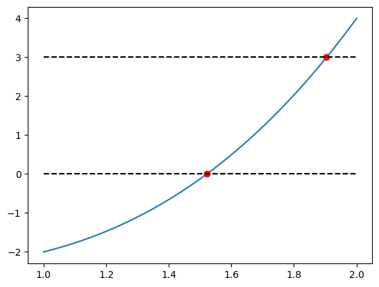

```python
import matplotlib.pyplot as plt
x_vals = np.linspace(1, 2, 400)
y_vals = func(x_vals)
plt.plot(x_vals, y_vals, label='f(x)')
plt.plot([root1, root2], [0, 3], 'ro')
plt.plot([1,2], [0,0], 'k--')
plt.plot([1,2], [3,3], 'k--')
plt.show()
```

### Erweiterung der Klasse um die Newton Methode

Wenn die Funktion $f$ differenzierbar ist (also wenn die Ableitung $f'$ existiert), so kann die Newton Methode verwendet werden, um Nullstellen zu finden. Diese Methode konvergiert in der Regel schneller als die Bisektionsmethode, erfordert jedoch eine Anfangsnäherung und die Berechnung der Ableitung.

- Die Berechnungsvorschrift der Newton Methode lautet: $$ x_{n+1} = x_n - \frac{f(x_n)}{f'(x_n)} $$
- Wenn die Newton Methode konvergiert, so verdoppelt sich die Anzahl der korrekten Nachkommastellen in jedem Schritt.
- Beim Bisektionsverfahren hingegen erhöht sich die Anzahl der korrekten Nachkommastellen etwa alle 3 bis 4 Schritte um eine.
- Die Newton Methode ist empfindlich gegenüber der Wahl des Startwerts und kann fehlschlagen, wenn die Ableitung nahe null ist oder wenn der Startwert weit von der tatsächlichen Nullstelle entfernt ist.
- In diesem Fall ruft die Klasse die robustere Bisektionsmethode auf.

```python
class NewtonSolver(Solver):
    def __init__(self, func, dfunc):
        super().__init__(func)
        self.dfunc = dfunc  # Ableitungsfunktion

    def solve(self, rhs, a, b, tol=1e-7, max_iter=100):
        solution = self.check_rhs(rhs, tol)
        if solution is not None:
            return solution, 0  # Rückgabe der gespeicherten Lösung und 0 Iterationen
        func = lambda x: self.func(x) - rhs
        root, iterations = self.newton(func, a, b, 0.5*(a+b), tol, max_iter)
        if root is None:
            print("Newton Method failed, trying bisection instead...")
            root, iterations = self.bisection(func, a, b, tol, max_iter)
        self.add_solution(rhs, root)
        return root, iterations

    def newton(self, func, a, b, x0, tol, max_iter):
        x = x0
        for j in range(max_iter):
            f_x = func(x)
            d_f_x = self.dfunc(x)
            if abs(f_x) < tol:
                return x, j+1  # Rückgabe der Nullstelle und der Anzahl der Iterationen
            if abs(d_f_x) < 1e-12:
                return None, j+1
            x -= f_x / d_f_x
            if x < a or x > b:
                return None, j+1
        return None, max_iter


solve = NewtonSolver(lambda x: x**3-x-2, lambda x: 3*x**2-1)
root, iterations = solve.solve(0, 1, 3)
print(f"Die Lösung von x^3-x-2 = 0 ist: {root:.7f} (gefunden in {iterations} Iterationen)")
root, iterations = solve.solve(3, 1, 3)
print(f"Die Lösung von x^3-x-2 = 3 ist: {root:.7f} (gefunden in {iterations} Iterationen)")
root, iterations = solve.solve(0, 1, 3)
print(f"Die Lösung von x^3-x-2 = 0 ist: {root:.7f} (gefunden in {iterations} Iterationen)")
```

```
Die Lösung von x^3-x-2 = 0 ist: 1.5213797 (gefunden in 5 Iterationen)
Die Lösung von x^3-x-2 = 3 ist: 1.9041609 (gefunden in 4 Iterationen)
Die Lösung von x^3-x-2 = 0 ist: 1.5213797 (gefunden in 0 Iterationen)
```

### Fehlschlagen der Newton Methode

Ein klassisches Beispiel, wo die Newton Methode fehlschlägt, ist die Funktion $f(x) = \arctan(x)$ mit der Ableitung $f'(x) = \frac{1}{1+x^2}$.

```python
solve = NewtonSolver(lambda x: np.atan(x), lambda x: 1/(1+x**2))
root, iterations = solve.solve(0, -1, 5)
print(f"Die Lösung von arctan(x) = 0 ist: {root:.7f} (gefunden in {iterations} Iterationen)")
```

```
Newton Method failed, trying bisection instead...
Die Lösung von arctan(x) = 0 ist: -0.0000001 (gefunden in 25 Iterationen)
```

Um zu verstehen, warum die Newton Methode in diesem Fall fehlschlägt, plotten wir die Iterationen der Newton Methode.

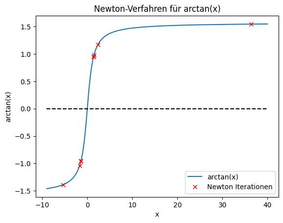

```python
def newton_plot(func, dfunc, a, b, x0, tol, max_iter):
        x = x0
        hist = np.array([x0])
        for j in range(max_iter):
            f_x = func(x)
            d_f_x = dfunc(x)
            if abs(f_x) < tol:
                return x, hist
            if abs(d_f_x) < 1e-12:
                return None, j+1
            x -= f_x / d_f_x
            hist = np.append(hist, x)
            if x < a or x > b:
                return None, hist
        return None, hist

_, hist = newton_plot(lambda x: np.atan(x), lambda x: 1/(1+x**2), -100, 100, 1.394, 1e-7, 100)

hist = hist[:-1]
import matplotlib.pyplot as plt
x_vals = np.linspace(-9, 40, 400)
plt.plot(x_vals, np.arctan(x_vals), label='arctan(x)')
plt.plot(hist, np.arctan(np.array(hist)), 'rx', label='Newton Iterationen')
plt.plot([ -9, 40], [0, 0], 'k--')
plt.xlabel('x')
plt.ylabel('arctan(x)')
plt.title('Newton-Verfahren für arctan(x)')
plt.legend()
plt.show()
```

# Symbolisches Rechnen mit `SymPy`

- `SymPy` ist eine Python-Bibliothek für symbolisches Rechnen.
- Es ermöglicht die Manipulation und Vereinfachung von mathematischen Ausdrücken, das Lösen von Gleichungen, das Differenzieren und Integrieren von Funktionen und vieles mehr.
- `SymPy` ist besonders nützlich für Aufgaben, die über numerische Berechnungen hinausgehen und eine symbolische Darstellung erfordern.
- Installation: `pip install sympy`

## Definieren von Symbolen (= Unbekannten)

Die Funktion `symbols` wird verwendet, um symbolische Variablen zu definieren. Diese Variablen können dann in mathematischen Ausdrücken verwendet werden.

```
from sympy import symbols
x, y = symbols('display_name_x display_name_y')
```

- Hier sind `x` und `y` symbolische Variablen, die in späteren Berechnungen verwendet werden können.
- Die Argumente von `symbols` sind die Namen, die in der Ausgabe verwendet werden. Sie können von den Variablennamen im Code abweichen.
- Im Unterschied zu normalen Python-Variablen können symbolische Variablen nicht direkt mit Zahlen oder anderen Variablen verknüpft werden. Stattdessen werden sie in Ausdrücken verwendet, die später ausgewertet oder manipuliert werden können.

```python
from sympy import symbols
x, y = symbols('x y')
expr = x**2 + 2*x*y + y**2
```

## Auswerten von Ausdrücken

Die Funktion `evalf()` wird verwendet, um symbolische Ausdrücke numerisch auszuwerten.

- Jede Variable im Ausdruck muss zuvor definiert worden sein.
- Die Werte der Variablen werden als Dictionary übergeben, wobei die Schlüssel die symbolischen Variablen und die Werte die numerischen Werte sind.

```python
print("Let x = 1 and y = 2. Then,", expr, "=", expr.evalf(subs={x: 1, y: 2}))
```

```
Let x = 1 and y = 2. Then, x**2 + 2*x*y + y**2 = 9.00000000000000
```

`SymPy` rechnet intern mit der Klasse `Float`, die eine höhere Präzision als die Standard-Python-Gleitkommazahlen bietet.

- `SymPy` versucht automatisch den Rundungsfehler zu schätzen und die Präzision der Berechnungen zu erhöhen, wenn dies erforderlich ist.

## Substitution von Variablen

Die Methode `subs()` wird verwendet, um symbolische Variablen in einem Ausdruck durch andere Ausdrücke oder Werte zu ersetzen.

- Sie nimmt ein Dictionary als Argument, in dem die Schlüssel die zu ersetzenden Variablen und die Werte die neuen Ausdrücke oder Werte sind.
- Will man nur eine Variable ersetzen, kann `subs` auch mit zwei Argumenten aufgerufen werden: `expr.subs(old, new)`.
- Wenn alle Variablen durch numerische Werte ersetzt wurden, kann der Ausdruck mit `evalf()` ausgewertet werden.

```python
a, b = symbols('a b')
expr2 = expr.subs({x: a + 1, y: b - 1})
print("After substitution:", expr2)
print("After substitution and evaluation at a=1, b=2:", expr2.subs({a: 1, b: 2}).evalf())
```

```
After substitution: (a + 1)**2 + 2*(a + 1)*(b - 1) + (b - 1)**2
After substitution and evaluation at a=1, b=2: 9.00000000000000
```

## Manipulation von Ausdrücken

`SymPy` bietet eine Vielzahl von Funktionen zur Manipulation und Vereinfachung von Ausdrücken, wie z.B. `expand()`, `factor()`, `simplify()`, etc

- `expand()`: Rechnet Produkte aus und entwickelt Potenzen
- `factor()`: Faktorisierung von Ausdrücken
- `simplify()`: Versucht, den Ausdruck zu vereinfachen

```python
expr = (x + y)**2
expr2 = x**3 + 3*x**2*y + 3*x*y**2 + y**3
print("Expanded:", expr, "=", expr.expand())
print("Factored:", expr2, "=", expr2.factor())
print("Simplified:", (x**2 - y**2)/(x - y), "=", ((x**2 - y**2)/(x - y)).simplify())
```

```
Expanded: (x + y)**2 = x**2 + 2*x*y + y**2
Factored: x**3 + 3*x**2*y + 3*x*y**2 + y**3 = (x + y)**3
Simplified: (x**2 - y**2)/(x - y) = x + y
```

- `collect()`: Sammelt Terme mit gemeinsamen Faktoren
- `collect(x)`: Sammelt Terme mit gemeinsamen Faktoren in Bezug auf `x'

```python
from sympy import collect, together, apart

# Example for collect
expr3 = x**2 + 2*x*y + y**2 + x*y + x*y**2
collected_expr = collect(expr3, x)
print("Collected with respect to x:", collected_expr)
```

```
Collected with respect to x: x**2 + x*(y**2 + 3*y) + y**2
```

## Mathematische Funktionen in `SymPy`

`SymPy` bietet eine Vielzahl von mathematischen Funktionen, die in symbolischen Ausdrücken verwendet werden können. Einige der wichtigsten Funktionen sind:

- Trigonometrische Funktionen: `sin()`, `cos()`, `tan()`, `asin()`, `acos()`, `atan()`
- Exponential- und Logarithmusfunktionen: `exp()`, `log()`
- Hyperbolische Funktionen: `sinh()`, `cosh()`, `tanh()`
- Spezielle Funktionen: `gamma()`, `erf()`, `besselj()`, etc.

```python
from sympy import sin, cos
expr = sin(x)**2 + cos(x)**2
print("sin(x)^2 + cos(x)^2 =", expr.simplify())
```

```
sin(x)^2 + cos(x)^2 = 1
```

## Lösen von Gleichungen

Die Funktion `solve()` wird verwendet, um Gleichungen der folgenden Form symbolisch zu lösen:

```
Expression of Equation = 0
```

- Sie nimmt die Ausdrücke der Gleichung (oder eines Systems von Gleichungen als Liste ) und die Variable(n), die gelöst werden sollen, als Argumente
- `solve()` gibt die Lösungen als Liste zurück
  - bei mehreren Variablen als Dictionary
  - bei mehreren Lösungen und mehreren Variablen als Liste von Tupeln
- Die rechte Seite der Gleichung wird implizit als 0 angenommen, d.h. die Gleichung $x^2 = 4$ muss zuerst umgeformt werden zu $x^2 - 4 = 0$.

```python
from sympy import solve
sols = solve(x**2 - 4, x)
print("Solutions of x^2 - 4 = 0:", sols)
sols = solve([x**2-4, y**2-1], (x, y))
print("Solutions of the system of equations x^2 = 4 and y^2 = 1:", sols)
sols = solve([x + y - 3, x - y - 1], (x, y))
print("Solutions of the system of equations x + y = 3 and x - y = 1:", sols)
```

```
Solutions of x^2 - 4 = 0: [-2, 2]
Solutions of the system of equations x^2 = 4 and y^2 = 1: [(-2, -1), (-2, 1), (2, -1), (2, 1)]
Solutions of the system of equations x + y = 3 and x - y = 1: {x: 2, y: 1}
```

### Welche Gleichungen können gelöst werden?

`solve` kann viele, aber bei weitem nicht alle Gleichungen lösen. Unter anderem können folgende Typen von Gleichungen gelöst werden:

- Polynomiale Gleichungen (z.B. quadratische, kubische Gleichungen)
- Lineare Gleichungssysteme
- Einige spezielle Funktionen (z.B. Exponential-, Logarithmus-, Trigonometrische Funktionen)
- Rationale Gleichungen (Brüche von Polynomen)

Für komplexere Gleichungen oder Gleichungssysteme kann es notwendig sein, spezialisierte Funktionen oder numerische Methoden zu verwenden.

```python
sols = solve(sin(cos(x)+sin(x)), x)
print("Solutions of x^6 - x^3 - 2 = 0:", sols)
```

[output not shown]

### Beispiel: Interpolation

Die Aufgabe der Interpolation besteht darin, eine Funktion zu finden, die durch eine gegebene Menge von Punkten verläuft. Ein quadratisches Polynom kann durch drei Punkte eindeutig bestimmt werden, und daher auch drei Punkte interpolieren.

Wir suchen also ein Polynom der Form $p(x) = a x^2 + b x + c$, das durch die Punkte $(x_0, y_0)$, $(x_1, y_1)$ und $(x_2, y_2)$ verläuft. $$ p(x_i) = y_i \quad \text{für } i = 0, 1, 2 $$

```
Interpolating polynomial: -3*x**2/2 + 5*x/2 + 1
```

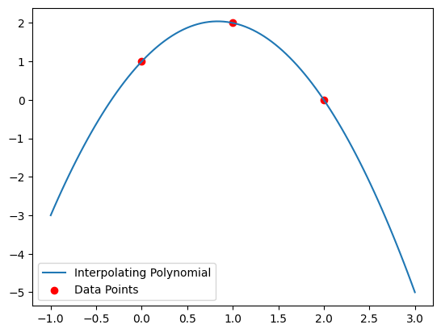

```python
import sympy as sp
x, a, b, c = sp.symbols('x a b c')
points =  [(0, 1), (1, 2), (2, 0)]
p = a*x**2 + b*x + c
equations = [p.subs(x, x0) - y0 for x0, y0 in points]
solutions = sp.solve(equations, (a, b, c))
p_interpolating = p.subs(solutions)
print("Interpolating polynomial:", p_interpolating)

# Plotting the points and the polynomial
import numpy as np
import matplotlib.pyplot as plt

x_vals = np.linspace(-1, 3, 100)
y_vals = [p_interpolating.evalf(subs={x : val}) for val in x_vals]
plt.plot(x_vals, y_vals, label='Interpolating Polynomial')
px, py = zip(*points)
plt.scatter(px, py, color='red', label='Data Points')
plt.legend()
plt.show()
```

### Alternative: `interpolate` Funktion

Anstatt die Interpolation manuell durchzuführen, können wir die `interpolate` Funktion von SymPy verwenden, um das gleiche Ergebnis zu erzielen.

```python
p = sp.interpolate(points, x)
print("Interpolating polynomial using interpolate function:", p)
```

```
Interpolating polynomial using interpolate function: -3*x**2/2 + 5*x/2 + 1
```

## Differenzieren und Integrieren

`SymPy` bietet Funktionen zum symbolischen Differenzieren und Integrieren von Ausdrücken:

- `diff()`: Differenziert einen Ausdruck nach einer oder mehreren Variablen
- `integrate()`: Integriert einen Ausdruck nach einer oder mehreren Variablen

```python
f = x**3 + 2*x**2 + x + 1
f_diff = sp.diff(f, x)
f_int = sp.integrate(f, x)
print("Function:", f)
print("Derivative:", f_diff)
print("Indefinite Integral:", f_int)
print("Integral from a to b:", sp.integrate(f, (x, a, b)))
```

```
Function: x**3 + 2*x**2 + x + 1
Derivative: 3*x**2 + 4*x + 1
Indefinite Integral: x**4/4 + 2*x**3/3 + x**2/2 + x
Integral from a to b: -a**4/4 - 2*a**3/3 - a**2/2 - a + b**4/4 + 2*b**3/3 + b**2/2 + b
```

### Beispiel: Textaufgabe

Finden Sie eine Parabel, die durch die den Hochpunkt bei $x=0$ hat, Nullstellen bei $x=-1$ und $x=1$, und welche mit der $x$-Achse eine Fläche von 2 einschließt.

```
Parabel: 3/2 - 3*x**2/2
```

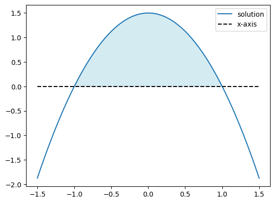

```python
import sympy as sp
x, a, b, c = sp.symbols('x a b c')
f = a*(x**2) + b*x + c
# Hochpunkt bei x=0 => f'(0) = 0
eq1 = sp.diff(f,x).subs(x, 0)
# Nullstellen bei x=-1 und x=1 => f(-1) = 0 und f(1) = 0
eq2a = f.subs(x, -1)
eq2b = f.subs(x, 1)
# Fläche von 2 mit der x-Achse => Integral von f
eq3 = sp.integrate(f, (x, -1, 1)) - 2

solutions = sp.solve([eq1, eq2a, eq2b, eq3], (a, b, c))
f_solution = f.subs(solutions)
print("Parabel:", f_solution)

# Plotting the solution
import numpy as np
import matplotlib.pyplot as plt
x_vals = np.linspace(-1.5, 1.5, 100)
y_vals = np.array([f_solution.evalf(subs={x : val}) for val in x_vals], dtype=np.float64)
plt.plot(x_vals, y_vals, label='solution')
plt.plot(x_vals, np.zeros_like(x_vals), 'k--', label='x-axis')
plt.fill_between(x_vals, y_vals, where=(y_vals > 0), color='lightblue', alpha=0.5)
plt.legend()
plt.show()
```

# Bäume (Trees)

Ein Baum ist eine Menge von Knoten (Nodes), die Eltern-Kind-Beziehungen haben.

- Jeder Knoten kann mehrere Kinder haben, aber höchstens einen Elternknoten.
- Es gibt genau einen Knoten ohne Eltern, den sogenannten Wurzelknoten (Root).
- Knoten ohne Kinder werden Blätter (Leaves) genannt.

Ein Spezialfall eines Baumes ist der binäre Baum, bei dem jeder Knoten entweder null, oder zwei Kinder hat. (Manchmal ist auch ein Kind erlaubt.)

Um Bäume in Python zu realisieren, braucht man eine Klasse für die Knoten. Diese Klasse enthält:

- Daten, die der Knoten speichern soll
- Eine Liste von Kindknoten
- evtl. Methoden, um Kinder hinzuzufügen und zu entfernen
- evtl. den Elternknoten

```python
class Node:
    def __init__(self, value):
        self.value = value
        self.children = []
        self.parent = None

    def add_child(self, child_node):
        child_node.parent = self
        self.children.append(child_node)
```

Manchmal ist es auch sinnvoll, eine eigene Klasse für den Baum zu definieren, die den Wurzelknoten und andere Baum-Methoden enthält.

- `get_ancestors(node)`: Gibt alle Vorfahren eines Knotens zurück.
- `plot()`: Visualisiert den Baum mit `matplotlib`

Alternativ kann man Bäume auch mit verschachtelten Listen oder Dictionaries darstellen, aber das ist oft unübersichtlich und schwer zu handhaben.

```python
class Tree:
    def __init__(self,value):
        self.root = Node(value)

    def get_ancestors(self, node):
        ancestors = []
        current = node
        while current.parent is not None:
            ancestors.append(current.parent)
            current = current.parent
        return ancestors

    def plot(self):
        import matplotlib.pyplot as plt
        def _plot_node(node, x, y, dx, ax, depth=0):
            ax.text(x, y, str(node.value), ha='center', va='center', bbox=dict(boxstyle="circle", fc="w"))
            if node.children:
                next_y = y - 1
                width = dx * (len(node.children) - 1)
                for i, child in enumerate(node.children):
                    next_x = x - width/2 + i*dx
                    ax.plot([x, next_x], [y, next_y], 'k-')
                    _plot_node(child, next_x, next_y, dx/2, ax, depth+1)

        fig, ax = plt.subplots(figsize=(5,3))
        ax.axis('off')
        _plot_node(self.root, x=0, y=0, dx=2, ax=ax)
        plt.show()
```

Wir erstellen einen kleinen binären Baum

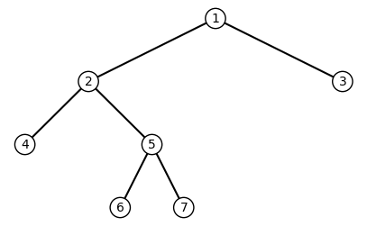

```
Vorfahren von Knoten 6: [5, 2, 1]
```

```python
tr = Tree(1)
n1 = Node(2)
n2 = Node(3)
tr.root.add_child(n1)
tr.root.add_child(n2)
n3 = Node(4)
n4 = Node(5)
n1.add_child(n3)
n1.add_child(n4)
n5 = Node(6)
n6 = Node(7)
n4.add_child(n5)
n4.add_child(n6)
# Visualisierung des Baums
tr.plot()
# Vorfahren von Knoten 6 ausgeben
print("Vorfahren von Knoten 6:", [node.value for node in tr.get_ancestors(n5)])
```

## Beispiel: Min-Max Algorithmus

Bäume werden oft verwendet um Entscheidungsprozesse zu modellieren. Als Beispiel betrachten wir das Spiel Tic-Tac-Toe:

- Zwei Spieler (X und O) setzen abwechselnd ihre Zeichen auf ein 3x3 Gitter.
- Ziel ist es, drei eigene Zeichen in einer Reihe (horizontal, vertikal oder diagonal) zu haben.
- Das Spiel endet, wenn ein Spieler gewinnt oder alle Felder besetzt sind (Unentschieden).

Wir speichern den Spielzustand in einem Baum:

- Der Root-Knoten repräsentiert den Anfangszustand (leeres Gitter).
- Jeder Knoten hat Kinder, die die möglichen Spielzüge darstellen.
  - Im Unterschied zu oben verwenden wir hier ein Dictionary, um die Kinder zu speichern, damit wir den Zug der vom aktuellen Knoten zum Kind führt als Schlüssel speichern können.
- Jeder Knoten speichert, welcher Spieler am Zug ist (`player`),
- und den aktuellen Spielzustand (`game_state`)

```python
import copy
class TreeNode:
    node_count  = 1
    def __init__(self, value):
        self.value = value
        self.player = None
        self.game_state = None
        self.children = dict()
    def add_child(self, child_node, move):
        self.children[move] = child_node
        TreeNode.node_count += 1
    def determine_winner(self):
        lines = self.game_state + [list(col) for col in zip(*self.game_state)] + [[self.game_state[i][i] for i in range(3)], [self.game_state[i][2-i] for i in range(3)]]
        for line in lines:
            if line[0] is not None and all(cell == line[0] for cell in line):
                self.value = 1 if line[0] == 'X' else -1
                return
        if all(cell is not None for row in self.game_state for cell in row):
            self.value = 0
            return
        self.value = None
    def update(self):
        if self.value is not None:
            return self.value
        if self.player == 'X':
            self.value = max(child.update() for child in self.children.values())
        else:
            self.value = min(child.update() for child in self.children.values())
        return self.value
    def __str__(self):
        state = "  1 2 3\n"
        for i, row in enumerate(self.game_state):
            state += f"{i+1} " + "|".join(cell if cell is not None else " " for cell in row) + "\n"
        return state
```

Die Klasse hat 3 neue Methoden: `determine_winner()`, `update()` und `__str__()`.

**`determine_winner()`** überprüft, ob ein Spieler im aktuellen Zug (Node) gewonnen hat oder ob das Spiel unentschieden ist.

- Dazu werden zuerst alle möglichen Linien (horizontal, vertikal, diagonal) des Gitters in einer Liste gespeichert.
  - `self.game_state` ist bereits eine Liste der horizontalen Linien.
  - Die vertikalen Linien werden mit einer List Comprehension und `zip` erstellt.
    - `zip(*self.game_state)` entspricht `zip(self.game_state[0], self.game_state[1], self.game_state[2])` und erzeugt Tupel der vertikalen Linien.
  - Die diagonalen Linien werden manuell mit List-Comprehensions erstellt.
- Dann wird überprüft, ob eine der Linien nur aus 'X's oder nur aus 'O's besteht.
  - Wenn ja, wird in `self.value` 1 (für 'X' gewinnt) oder -1 (für 'O' gewinnt) gespeichert
- Fall kein Gewinner ermittelt werden kann und alle Felder belegt sind, ist das Spiel unentschieden und `self.value` wird auf 0 gesetzt.
- Ansonsten wird `self.value` auf `None` gesetzt, was bedeutet, dass das Spiel noch nicht beendet ist.

__`__str__()`__ gibt eine String-Darstellung des Spielzustands zurück, die das Gitter in einer lesbaren Form darstellt.

### Min-Max Algorithmus in `update()`

Die Methode `update()` implementiert den Min-Max Algorithmus, der in Zwei-Personenen-Spielen verwendet wird, um den optimalen Zug zu bestimmen.

- Wenn der Knoten bereits einen Wert (`self.value`) hat, wird dieser zurückgegeben.
- Wenn der Spieler am Zug 'X' ist, wird der maximale Wert der Kindknoten berechnet (da 'X' versucht zu gewinnen, also `1` zu erreichen).
- Wenn der Spieler am Zug 'O' ist, wird der minimale Wert der Kindknoten berechnet (da 'O' versucht zu gewinnen, also `-1` zu erreichen).
- Der berechnete Wert wird in `self.value` gespeichert und zurückgegeben.

Der Min-Max Algorithmus bewertet rekursiv alle möglichen Spielzüge und deren Ergebnisse.

- Somit kann der beste Zug für den aktuellen Spieler bestimmt werden, indem man den Kindknoten mit dem besten Wert auswählt.
- Min-Max liefert immer eine optimale Strategie für beide Spieler
- Min-Max muss den gesamten Spielbaum aufbauen und durchsuchen, was bei komplexeren Spielen sehr rechenintensiv sein kann.
  - Oft kann man durch abscheiden (pruning) Teile des Baumes ignorieren, die keinen Einfluss auf das Endergebnis haben.
  - Unsere Implementierung von Tic-Tac-Toe benötigt 549946 Knoten
    - Es kommen Spielzustände mehrfach vor, da unterschiedliche Zugfolgen zum gleichen Ergebnis führen können
  - "4 Gewinnt" (oder "Connect Four") hat 4,531,985,219,092 verschiedene Spielzustände
  - "Schach" hat ca. $10^{120}$ mögliche Spielverläufe (die Zahl der Atome im beobachtbaren Universum wird auf ca. $10^{80}$ geschätzt)

Der folgende Code generiert den gesamten Spielbaum für Tic-Tac-Toe und berechnet die optimalen Züge mit Min-Max. Der Wert des Wurzelknotens is besonders interessant

- Ein Wert von `1` bedeutet, dass der Spieler, der zuerst zieht (X), mit optimaler Strategie gewinnen kann.
- Ein Wert von `-1` bedeutet, dass der zweite Spieler (O) mit optimaler Strategie gewinnen kann.
- Ein Wert von `0` bedeutet, dass das Spiel bei optimaler Strategie beider Spieler unentschieden endet (Das ist bei Tic-Tac-Toe der Fall).

Bemerkung:

- Bei "4 Gewinnt" kann der erste Spieler mit optimaler Strategie immer gewinnen (egal was der zweite Spieler macht).
- Bei "Schach" ist diese Frage noch offen (es wird vermutet, dass bei optimaler Strategie beider Spieler das Spiel unentschieden endet).

```python
root = TreeNode(None)
root.game_state = [[None, None, None], [None, None, None], [None, None, None]]
root.player = 'X'
def generate_children(curr_node):
    curr_node.determine_winner()
    if curr_node.value is not None:
        return
    for i, row in enumerate(curr_node.game_state):
        for j, cell in enumerate(row):
            if cell is None:
                child = TreeNode(None)
                child.game_state = copy.deepcopy(curr_node.game_state)
                child.game_state[i][j] = curr_node.player
                child.player = 'O' if curr_node.player == 'X' else 'X'
                curr_node.add_child(child,(i,j))
                generate_children(child)


generate_children(root)
print(f"Anzahl der Knoten im Baum: {TreeNode.node_count}")
root_value = root.update()
print(f"Wert des Wurzelknotens (optimaler Spielausgang für X): {root_value}")
```

```
Anzahl der Knoten im Baum: 549946
Wert des Wurzelknotens (optimaler Spielausgang für X): 0
```

### Beispiel: Tic-Tac-Toe Computer

Wir können den Spielbaum nun verwenden, um einen einfachen Tic-Tac-Toe Computer zu bauen, der immer den optimalen Zug macht.

- User (`X`) gibt den gewünschten Zug ein
- Computer sucht den entsprechenden Kindknoten im Baum und wählt den besten Antwort-Zug (falls mehrere möglich sind, wird zufällig gewählt)
- `print(...., flush=True)` sorgt dafür, dass die Ausgabe sofort angezeigt wird (kann sonst zu Konflikten mit der Eingabeaufforderung führen)

```python
import random
def play_game(root):
    print(root, flush=True)
    x,y = map(int,input("Enter row and col: ").split(" "))
    x -= 1
    y -= 1
    if root.children:
        if (x,y) in root.children:
            root = root.children[(x,y)]
        else:
            print("Invalid move!")
            play_game(root)
            return
        if root.children:
            best_value = min(child.value for child in root.children.values())
            best_moves = [child for child in root.children.values() if child.value == best_value]
            play_game(random.choice(best_moves))
        else:
            print("You win!" if root.value == 1 else "It's a draw!" if root.value == 0 else "Computer wins!")
    else:
        print("You win!" if root.value == 1 else "It's a draw!" if root.value == 0 else "Computer wins!")
        return

play_game(root)
```

```
  1 2 3
1  | |
2  | |
3  | |

  1 2 3
1 O| |
2  |X|
3  | |

  1 2 3
1 O|X|
2  |X|
3  |O|

  1 2 3
1 O|X|
2 O|X|X
3  |O|

  1 2 3
1 O|X|O
2 O|X|X
3 X|O|

It's a draw!
```

## Beispiel: Mesh-Refinement

- Mesh-Refinement ist eine Technik in der numerischen Mathematik, um die Genauigkeit von Simulationen zu verbessern.
- Dabei wird ein Gitter (Mesh) in kleinere Zellen unterteilt, um Bereiche mit hoher Variabilität genauer zu erfassen.
- Dies wird oft in der Finite-Elemente-Methode (FEM) verwendet, um komplexe geometrische Formen und physikalische Phänomene zu modellieren.
  - Mehr dazu in den Vorlesungen: **Numerik partieller Differentialgleichungen: (in)stationäre Probleme**

Wer erstellen zuerst eine Klasse `Element`, die ein einzelnes Dreieck im Gitter repräsentiert.

- Die Klasse speichert die Eckpunkte des Dreiecks
- Die Klasse speichert die Kinder und Eltern des Elements
- `marked` gibt an, ob das Element zur Verfeinerung markiert ist
- `refine()` teilt das Dreieck in vier kleinere ähnliche Dreiecke auf (Red-Refinement)
  - Dabei werden die Mittelpunkte der Seiten berechnet und als neue Eckpunkte verwendet
  - Die Kinder werden erstellt und die Eltern-Kind-Beziehungen werden gesetzt

```python
import numpy as np
class Element:
    def __init__(self, vertices):
        self.vertices = vertices  # 2x3 np.array of vertex coordinates in clockwise order
        self.children = []        # Sub-elements after refinement
        self.parent = None
        self.marked = False  # For adaptive refinement
    def center(self):
        return np.mean(self.vertices, axis=1)
    def refine(self):
        midpoints = 0.5*(self.vertices[:,[0,1,2]] + self.vertices[:,[1,2,0]])
        c1 = Element(np.block([midpoints[:,2:3], midpoints[:,1:2], self.vertices[:,2:3]]))
        c2 = Element(np.block([self.vertices[:,0:1],midpoints[:,0:1], midpoints[:,2:3]]))
        c3 = Element(np.block([midpoints[:,0:1],self.vertices[:,1:2], midpoints[:,1:2]]))
        c4 = Element(np.block([midpoints[:,2:3], midpoints[:,0:1], midpoints[:,1:2]]))
        self.children = [c1,c2,c3,c4]
        for child in self.children:
            child.parent = self
        return self.children
```

Wir implementieren dann eine Klasse `Mesh`, die das gesamte Gitter verwaltet.

- Die Klasse speichert eine Liste von Elementen
  - Diese Elemente sind die Blätter des Verfeinerungsbaums
- `refine_marked()` verfeinert alle markierten Elemente und aktualisiert die Liste der Blätter (`self.elements`)
- `coarsen()` macht eine Verfeinerung rückgängig, ersetzt also vier Kinder durch ihr Eltern-Element (wenn möglich)
- `plot()` visualisiert das Gitter mit `matplotlib`

```python
import matplotlib.pyplot as plt
class Mesh:
    def __init__(self, elements):
        self.elements = elements  # List of Element objects
    def refine_marked(self):
        new_elements = [e for e in self.elements if not e.marked]
        for elem in [e for e in self.elements if e.marked]:
            new_elements.extend(elem.refine())
        self.elements = new_elements
    def coarsen(self):
        to_remove = set()
        for elem in self.elements:
            if elem.parent and all(child in self.elements for child in elem.parent.children):
                to_remove.add(elem)
                self.elements.append(elem.parent)
        self.elements = [e for e in self.elements if e not in to_remove]
    def plot(self):
        for elem in self.elements:
            plt.plot(elem.vertices[0,[0,1,2,0]], elem.vertices[1,[0,1,2,0]], 'b-')
        plt.gca().set_aspect('equal')
```

Wir erstellen ein einfaches Beispielgitter und führen einige Verfeinerungen und eine Vergröberung durch.

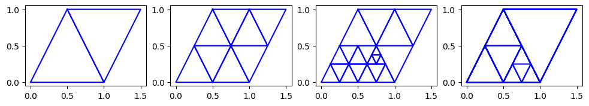

```python
# Initiales Dreieck
T0 = Element(np.array([[0.5,1,0],[1,0,0]]))
T1 = Element(np.array([[0.5,1.5,1],[1, 1,0]]))

# Mesh
mesh = Mesh([T0,T1])
plt.subplots(1,4,figsize=(12,3))
plt.subplot(1,4,1)
mesh.plot()
mesh.elements[0].marked = True
mesh.elements[1].marked = True
mesh.refine_marked()
plt.subplot(1,4,2)
mesh.plot()
mesh.elements[2].marked = True
mesh.elements[3].marked = True
mesh.refine_marked()
mesh.elements[0].marked = True
mesh.elements[7].marked = True
mesh.refine_marked()
plt.subplot(1,4,3)
mesh.plot()

mesh.coarsen()
plt.subplot(1,4,4)
mesh.plot()
plt.show()
```

### Anwendung: 2D Approximation

Eine einfache aber wichtige Anwendung ist die Approximation von Funktionen auf einem Mesh. Dazu definieren wir eine Klasse `PWLinear`, die von `Mesh` erbt und eine stückweise lineare Approximation implementiert.

- `approximate(f)` berechnet den Wert einer Funktion `f` an jeder Ecke des Elements und speichert diesen Wert in `self.values`
- `mark_elements(f, tol)` markiert alle Elemente, bei denen der Unterschied zwischen dem linear interpoliertem Wert im Schwerpunkt des Elements und der tatsächlichen Funktion größer als `tol` ist.
- `plot()` visualisiert das Gitter und die approximierte Funktion in einem 3D-Plot mit `matplotlib`
- `refine_marked()` wird neu definiert
  - Zuerst wird die Methode der Elternklasse aufgerufen, um die markierten Elemente zu verfeinern
  - Dann wird die Liste `self.values` auf die neue Anzahl der Elemente angepasst und mit 0 initialisiert

```python
class PWLinear(Mesh):
    def __init__(self, elements):
        super().__init__(elements)
        self.values = np.zeros((len(elements),3))  # Nodal values
    def refine_marked(self):
        super().refine_marked()
        self.values = np.zeros((len(self.elements),3))  # Reset values after refinement
    def approximate(self, f):
        for i, elem in enumerate(self.elements):
            for j in range(3):
                self.values[i,j] = f(elem.vertices[0,j], elem.vertices[1,j])
    def mark_elements(self, f, tol):
        for i, elem in enumerate(self.elements):
            c = elem.center()
            if np.abs(f(c[0],c[1]) - np.mean(self.values[i,:])) > tol:
                elem.marked = True
    def plot(self):
        fig = plt.figure()
        ax = fig.add_subplot(111, projection='3d')
        for i, elem in enumerate(self.elements):
            verts = elem.vertices
            ax.plot_trisurf(verts[0], verts[1], self.values[i,:], color=plt.cm.viridis(np.mean(self.values[i,:])), alpha=0.5, edgecolor='k')
        plt.show()
```

Wir testen die Klasse an der Funktion $f(x,y) = \cos(\pi x) y^4$.

- Wir beobachten, dass nach mehrern Verfeinerungen die Approximation immer genauer wird.
- In Bereichen, wo die Funktion $f$ sich nicht stark ändert, bleiben die Elemente groß, während in Bereichen mit hoher Variabilität die Elemente kleiner werden.

```
After 3 adaptive refinements:
```

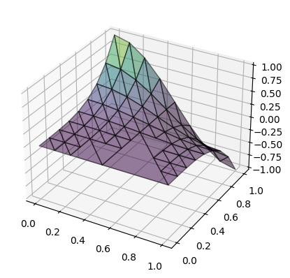

```
After 5 adaptive refinements:
```

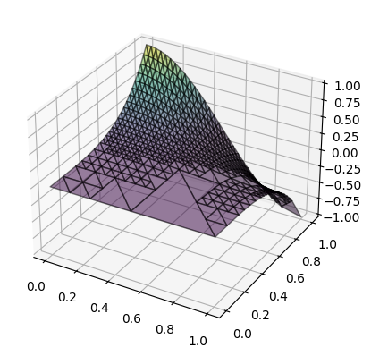

```python
mesh = PWLinear([Element(np.array([[0,1,0],[1,0,0]])), Element(np.array([[0,1,1],[1,1,0]]))])

f = lambda x,y: np.cos(np.pi*x)*y**4
mesh.approximate(f)
for _ in range(3):
    mesh.mark_elements(f, tol=0.001)
    mesh.refine_marked()
    mesh.approximate(f)
print("After 3 adaptive refinements:")
mesh.plot()
for _ in range(2):
    mesh.mark_elements(f, tol=0.001)
    mesh.refine_marked()
    mesh.approximate(f)
print("After 5 adaptive refinements:")
mesh.plot()
```

Die originale Funktion sieht so aus:

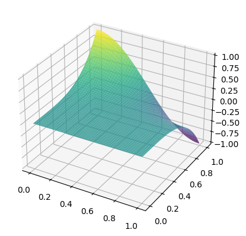

```python
X, Y = np.meshgrid(np.linspace(0,1,100), np.linspace(0,1,100))
Z = np.cos(np.pi*X)*Y**4
fig = plt.figure()
ax = fig.add_subplot(111, projection='3d')
ax.plot_surface(X, Y, Z, cmap='viridis', alpha=0.8)
plt.show()
```